# 03_starfish

Gulnara Tagridzhanova

21/03/2025

**Summary:** try detecting Starships in Xanthoria genome. This is a streamlined version of the document, that doesn’r include (many) failed attempts and tangents.

## 1. Installing Starfish

click to see

- Download date 20.05.2024

```r
ssh software
cd /tsl/scratch/gol22pin/singularity/
singularity pull starfish.sif oras://ghcr.io/egluckthaler/starfish:latest
singularity pull starfish oras://ghcr.io/egluckthaler/starfish:latest
```

- Tried and confirmed it works

```r
singularity run ../singularity/starfish.sif starfish -h
```

## 2. Assembling dataset

- Included 3 genomes from Xanthoria parietina and one X. calcicola
  - Xanthoria parietina GTX0501 already annotated
  - Xanthoria calcicola GTX0491 already annotated
  - new X. parietina genome produced by Aquatic Symbiosis Genome project (GCA_964656405, SAMEA111342678). Will annotate below
  - new X. parietina genome shared by Ellen Cameron (not public yet). Will annotate below
- All genomes annotated with Funannotate

## 3. Prep files

click to see re-formatting of various files

#### Pre-prepared assemblies and annotations

- Copied all genomes, gff, and protein fastas in a new folder

```r
mkdir analysis_and_temp_files/03_starfish/genomes

cp analysis_and_temp_files/02_annotate/GCA964656405_pred/annotate_results/Xanthoria_parietina_SAMEA111342678.scaffolds.fa analysis_and_temp_files/03_starfish/genomes
cp analysis_and_temp_files/02_annotate/GCA964656405_pred/annotate_results/Xanthoria_parietina_SAMEA111342678.gff3 analysis_and_temp_files/03_starfish/genomes
cp analysis_and_temp_files/02_annotate/GCA964656405_pred/annotate_results/Xanthoria_parietina_SAMEA111342678.proteins.fa analysis_and_temp_files/03_starfish/genomes

cp analysis_and_temp_files/02_annotate/SAMEA115359166_pred/annotate_results/Xanthoria_parietina_SAMEA115359166.scaffolds.fa analysis_and_temp_files/03_starfish/genomes
cp analysis_and_temp_files/02_annotate/SAMEA115359166_pred/annotate_results/Xanthoria_parietina_SAMEA115359166.gff3 analysis_and_temp_files/03_starfish/genomes
cp analysis_and_temp_files/02_annotate/SAMEA115359166_pred/annotate_results/Xanthoria_parietina_SAMEA115359166.proteins.fa analysis_and_temp_files/03_starfish/genomes

cp  ../02_long_read_assemblies/analysis_and_temp_files/06_annotate_lecanoro/GTX0501_pred/annotate_results/Xanthoria_parietina_GTX0501.scaffolds.fa analysis_and_temp_files/03_starfish/genomes analysis_and_temp_files/03_starfish/genomes
cp ../02_long_read_assemblies/analysis_and_temp_files/06_annotate_lecanoro/GTX0501_pred/annotate_results/Xanthoria_parietina_GTX0501.gff3 analysis_and_temp_files/03_starfish/genomes
cp ../02_long_read_assemblies/analysis_and_temp_files/06_annotate_lecanoro/GTX0501_pred/annotate_results/Xanthoria_parietina_GTX0501.proteins.fa analysis_and_temp_files/03_starfish/genomes

cp analysis_and_temp_files/02_annotate/GTX0491_pred/annotate_results/Xanthoria_calcicola_GTX0491.scaffolds.fa analysis_and_temp_files/03_starfish/genomes
cp analysis_and_temp_files/02_annotate//GTX0491_pred/annotate_results/Xanthoria_calcicola_GTX0491.gff3 analysis_and_temp_files/03_starfish/genomes
cp analysis_and_temp_files/02_annotate/GTX0491_pred/annotate_results/Xanthoria_calcicola_GTX0491.proteins.fa analysis_and_temp_files/03_starfish/genomes
```

- First, had to (again!) fix the names of the GCA964656405, since got an error downstream saying “is being parsed into <2 components using separator ’_’. Make sure ALL sequence headers are formatted like ”

```r
sed -i -e 's/OZ2100/OZ2100_/g' analysis_and_temp_files/03_starfish/genomes/Xanthoria_parietina_SAMEA111342678.scaffolds.fa
sed -i -e 's/OZ2100/OZ2100_/g' analysis_and_temp_files/03_starfish/genomes/Xanthoria_parietina_SAMEA111342678.gff3
```

- Next, had to edit the gff to change ID tag to Name tag

```r
sed -i 's/ID/Name/g' analysis_and_temp_files/03_starfish/genomes/Xanthoria_parietina_SAMEA111342678.gff3
sed -i 's/ID/Name/g' analysis_and_temp_files/03_starfish/genomes/Xanthoria_parietina_SAMEA115359166.gff3
sed -i 's/ID/Name/g' analysis_and_temp_files/03_starfish/genomes/Xanthoria_calcicola_GTX0491.gff3
sed -i 's/ID/Name/g' analysis_and_temp_files/03_starfish/genomes/Xanthoria_parietina_GTX0501.gff3
```

- Since I forgot to specify sequence tag for newly annotated genomes, had to replace them manually in gff and protein fasta files (otherwise both of them will have FUN_ sequence tag)

```r
sed -i 's/FUN_/XANPAOZ2100_/g' analysis_and_temp_files/03_starfish/genomes/Xanthoria_parietina_SAMEA111342678.gff3
sed -i 's/FUN_/XANPAOZ2100_/g' analysis_and_temp_files/03_starfish/genomes/Xanthoria_parietina_SAMEA111342678.proteins.fa

sed -i 's/FUN_/XANPARI20_/g' analysis_and_temp_files/03_starfish/genomes/Xanthoria_parietina_SAMEA115359166.gff3
sed -i 's/FUN_/XANPARI20_/g' analysis_and_temp_files/03_starfish/genomes/Xanthoria_parietina_SAMEA115359166.proteins.fa
```

- For the two genomes previously annotated, had to fix contig names to remove extra underscore

```r
sed -i 's/Xc_/Xc/g' analysis_and_temp_files/03_starfish/genomes/Xanthoria_calcicola_GTX0491.scaffolds.fa
sed -i 's/Xc_/Xc/g' analysis_and_temp_files/03_starfish/genomes/Xanthoria_calcicola_GTX0491.gff3

sed -i 's/Xp_/Xp/g' analysis_and_temp_files/03_starfish/genomes/Xanthoria_parietina_GTX0501.scaffolds.fa
sed -i 's/Xp_/Xp/g' analysis_and_temp_files/03_starfish/genomes/Xanthoria_parietina_GTX0501.gff3
```

#### Prep following starfish tutorial

- Starfish takes as input a tsv file with genome IDs and paths

```r
nano analysis_and_temp_files/03_starfish/ome2assembly.txt
    GTX0501  analysis_and_temp_files/03_starfish/genomes/Xanthoria_parietina_GTX0501.scaffolds.fa
    GTX0491  analysis_and_temp_files/03_starfish/genomes/Xanthoria_calcicola_GTX0491.scaffolds.fa
    GCA964656405  analysis_and_temp_files/03_starfish/genomes/Xanthoria_parietina_SAMEA111342678.scaffolds.fa
    SAMEA115359166 analysis_and_temp_files/03_starfish/genomes/Xanthoria_parietina_SAMEA115359166.scaffolds.fa


nano analysis_and_temp_files/03_starfish/ome2gff.txt
    GTX0501  analysis_and_temp_files/03_starfish/genomes/Xanthoria_parietina_GTX0501.gff3
    GTX0491  analysis_and_temp_files/03_starfish/genomes/Xanthoria_calcicola_GTX0491.gff3
    GCA964656405  analysis_and_temp_files/03_starfish/genomes/Xanthoria_parietina_SAMEA111342678.gff3
    SAMEA115359166 analysis_and_temp_files/03_starfish/genomes/Xanthoria_parietina_SAMEA115359166.gff3
```

- Concatanate assemblies and gff

```r
mkdir analysis_and_temp_files/03_starfish/blastdb

cut -f2 analysis_and_temp_files/03_starfish/ome2assembly.txt | xargs cat > analysis_and_temp_files/03_starfish/blastdb/manyxanthorias.assemblies.fna

cut -f2 analysis_and_temp_files/03_starfish/ome2gff.txt | xargs cat > analysis_and_temp_files/03_starfish/manyxanthorias.gff3
```

- Make index (samtools v1.18) and blast db

```r
source package c92263ec-95e5-43eb-a527-8f1496d56f1a
samtools faidx analysis_and_temp_files/03_starfish/blastdb/manyxanthorias.assemblies.fna
singularity run ../singularity/starfish.sif makeblastdb -in analysis_and_temp_files/03_starfish/blastdb/manyxanthorias.assemblies.fna -out analysis_and_temp_files/03_starfish/blastdb/manyxanthorias.assemblies -parse_seqids -dbtype nucl
```

- Calculate GC%. Couldn’t figure out how to run the script inside the singularity container, so instead saved it separately in the `code/` folder and ran outside

```r
source package b0ed0698-358b-4c9b-9d21-603ea8d6e478
bash code/seq-gc.sh -Nbw 1000 analysis_and_temp_files/03_starfish/blastdb/manyxanthorias.assemblies.fna  > analysis_and_temp_files/03_starfish/blastdb/manyxanthorias.assemblies.gcContent_w1000.bed
```

#### Parse emapper annotations

- Added the genome ID to the file name

```r
mkdir analysis_and_temp_files/03_starfish/ann

cp analysis_and_temp_files/02_annotate/GCA964656405_pred/annotate_misc/eggnog.emapper.annotations analysis_and_temp_files/03_starfish/ann/GCA964656405_eggnog.emapper.annotations

cp analysis_and_temp_files/02_annotate/SAMEA115359166_pred/annotate_misc/eggnog.emapper.annotations  analysis_and_temp_files/03_starfish/ann/SAMEA115359166_eggnog.emapper.annotations

cp  analysis_and_temp_files/06_annotate_lecanoro/GTX0501_pred/annotate_misc/eggnog.emapper.annotations analysis_and_temp_files/03_starfish/ann/GTX0501_eggnog.emapper.annotations

cp analysis_and_temp_files/06_annotate_lecanoro/GTX0491_pred/annotate_misc/eggnog.emapper.annotations analysis_and_temp_files/03_starfish/ann/GTX0491_eggnog.emapper.annotations
```

- For the new genomes, fixed the sequence tags

```r
sed -i 's/FUN_/XANPAOZ2100_/g' analysis_and_temp_files/03_starfish/ann/GCA964656405_eggnog.emapper.annotations
sed -i 's/FUN_/XANPARI20_/g' analysis_and_temp_files/03_starfish/ann/SAMEA115359166_eggnog.emapper.annotations
```

- Parse. “sorted 28381 sequences into 9999 ortholog groups..”

```r
cut -f1,21  analysis_and_temp_files/03_starfish/ann/*emapper.annotations | grep -v  '#' | grep -v -P '\t-' | perl -pe 's/\t/\tEMAP\t/' | grep -vP '\tNA' > analysis_and_temp_files/03_starfish/ann/manyxanthorias.gene2emap.txt

cut -f1,5 analysis_and_temp_files/03_starfish/ann/*emapper.annotations | grep -v '#' | perl -pe 's/(^.+?)\t.+,([^,]+)$/\1\t\2/' | perl -pe 's/@/\t/' > analysis_and_temp_files/03_starfish/ann/manyxanthorias.gene2og.txt

code/geneOG2mclFormat.pl -i analysis_and_temp_files/03_starfish/ann/manyxanthorias.gene2og.txt -o analysis_and_temp_files/03_starfish/ann
```

## 4. Gene finder module

- Annotate tyrosine recombinases

```r
mkdir analysis_and_temp_files/03_starfish/geneFinder
singularity run ../singularity/starfish.sif starfish annotate -T 10 -x many_xanthorias_tyr -a analysis_and_temp_files/03_starfish/ome2assembly.txt -g analysis_and_temp_files/03_starfish/ome2gff.txt -p /opt/conda/envs/starfish/db/YRsuperfams.p1-512.hmm -P /opt/conda/envs/starfish/db/YRsuperfamRefs.faa -i tyr -o analysis_and_temp_files/03_starfish/geneFinder

  Key parameters:
metaeuk        -v 3 -s 7.5 -e 0.0001 --max-intron 2000 --max-seqs 300 --metaeuk-eval 0.001 --exhaustive-search 1 --metaeuk-tcov 0.25 --allow-deletion 1 --protein 1 --disk-space-limit 100G --compressed 1
hmmsearch      --max -E 0.001
```

- STDOUT:
  - found 5 new tyr genes and 15 tyr genes that overlap with 16 existing genes
- Consolidate new tyr predictions and the pre-existing gff

```r
singularity run ../singularity/starfish.sif starfish consolidate -o analysis_and_temp_files/03_starfish/ -g analysis_and_temp_files/03_starfish/manyxanthorias.gff3 -G analysis_and_temp_files/03_starfish/geneFinder/many_xanthorias_tyr.filt_intersect.gff
```

- save file with the file path of the new gff

```r
realpath analysis_and_temp_files/03_starfish/many_xanthorias_tyr.filt_intersect.consolidated.gff | perl -pe 's/^/manyxanthoria\t/' > analysis_and_temp_files/03_starfish/ome2consolidatedGFF3.txt
```

- Tried to split genes into neighbourhoods (within 10 Kbp of each other),

```r
singularity run ../singularity/starfish.sif starfish sketch -m 10000 -q analysis_and_temp_files/03_starfish/geneFinder/many_xanthorias_tyr.filt_intersect.ids  -g analysis_and_temp_files/03_starfish/ome2consolidatedGFF3.txt -i s -x manyxanthoria -o analysis_and_temp_files/03_starfish/geneFinder/
```

- STDOUT:
  - merging any of the 20 input query genes within 10000 bp of each other into the same neighborhood..
  - extending neighborhoods by 0 flanking bp and adding all genes within new boundaries to neighborhood..
  - found 19 neighborhoods containing input query genes
- Pull coordinates of the captains

```r
grep -P '\ttyr\t' analysis_and_temp_files/03_starfish/geneFinder/manyxanthoria.bed > analysis_and_temp_files/03_starfish/geneFinder/manyxanthoria.tyr.bed
```

## 5. Element finder module

```r
mkdir analysis_and_temp_files/03_starfish/elementFinder

singularity run ../singularity/starfish.sif starfish insert -T 10 -a analysis_and_temp_files/03_starfish/ome2assembly.txt -d analysis_and_temp_files/03_starfish/blastdb/manyxanthorias.assemblies -b analysis_and_temp_files/03_starfish/geneFinder/manyxanthoria.tyr.bed -i tyr -x manyxanthoria -o analysis_and_temp_files/03_starfish/elementFinder/
```

- STDOUT:
  - parsing upstream regions of 19 candidate tyr captains..
  - searching for hits to the upstream regions of 19 candidate tyr captains..
  - found 15 tyr captains with candidate insertion sites
  - searching for hits to the downstream regions of candidate insertion sites for 15 tyr captains that are also downstream of those captains..
  - filtering out similar upstream and downstream flanks of insertion sites associated with 7 candidate tyr captains..
  - refining boundary predictions of 7 candidate tyr captains with insertion sites..
  - found 4 candidate tyr captains with refined insertion sites
  - aligning 4 candidate elements back to candidate insertion site contigs to make sure the element is really missing..
  - found element boundaries and insertion sites for 3 tyr captains out of 19 input captains
- This produced manyxanthoria.insert.bed and manyxanthoria.insert.stats, which contain **elements OZ2100_s00001 and scaffold_s00008**, which I will keep an eye on:

```r
stats1<-read.delim2("../analysis_and_temp_files/03_starfish/elementFinder/manyxanthoria.insert.stats")
stats1 %>% kable(format = "html", col.names = colnames(stats1)) %>%
  kable_styling() %>%
  kableExtra::scroll_box(width = "100%", height = "200px")
```

X.elementID

elementCaptainID

elementContigID

elementBegin

elementEnd

elementLength

elementStrand

emptyContigID

emptyBegin

emptyEnd

emptyLength

emptyStrand

emptySiteSeq

quality

warnings

OZ2100_s00003

OZ2100_tyr4

OZ2100_35

343880

361790

17911

scaffold_4

1106074

1108028

1955

.

ref

*empty site > 40 bp

OZ2100_s00001

OZ2100_002162-T1

OZ2100_30

304726

406787

102062

XcGTX0491_4

1852373

1852376

4

gcgg

ref

.

scaffold_s00008

scaffold_008752-T1

scaffold_12

662355

747238

84884

XcGTX0491_4

1852373

1852376

4

ccgc

ref

.

The tutorial says you can search for boundaries iteratively, but I will skip it here

Summarize

```r
singularity run ../singularity/starfish.sif starfish summarize -a analysis_and_temp_files/03_starfish/ome2assembly.txt -b analysis_and_temp_files/03_starfish/elementFinder/manyxanthoria.insert.bed -x manyxanthoria_round -o analysis_and_temp_files/03_starfish/elementFinder -S analysis_and_temp_files/03_starfish/elementFinder/manyxanthoria.insert.stats  -g analysis_and_temp_files/03_starfish/ome2consolidatedGFF3.txt -t analysis_and_temp_files/03_starfish/geneFinder/many_xanthorias_tyr.filt_intersect.ids
```

- STDOUT:
  - we have 0 elements with flank boundaries, 3 with insert boundaries, and 0 with extend boundaries, for a total of 3 elements
  - found 0 elements nested/overlapping with 0 other elements
- OZ2100_s00001 (from genome GCA964656405) and scaffold_s00008 (from genome SAMEA115359166) map to the same empty site in the GTX0491

```r
stats2<-read.delim2("../analysis_and_temp_files/03_starfish/elementFinder/manyxanthoria_round.elements.named.stats")
stats2 %>% kable(format = "html", col.names = colnames(stats2)) %>%
  kable_styling() %>%
  kableExtra::scroll_box(width = "100%", height = "200px")
```

X.elementID

elementCaptainID

elementContigID

elementBegin

elementEnd

elementLength

elementStrand

emptySiteID

emptyContigID

emptyBegin

emptyEnd

emptyLength

emptyStrand

emptySiteSeq

quality

warnings

OZ2100_s00003

OZ2100_tyr4

OZ2100_35

343880

361790

17911

scaffold_site001

scaffold_4

1106074

1108028

1955

.

ref

*empty site > 40 bp

OZ2100_s00001

OZ2100_002162-T1

OZ2100_30

304726

406787

102062

XcGTX0491_site001

XcGTX0491_4

1852373

1852376

4

gcgg

ref

.

scaffold_s00008

scaffold_008752-T1

scaffold_12

662355

747238

84884

XcGTX0491_site001

XcGTX0491_4

1852373

1852376

4

ccgc

ref

.

Assign to a family. This produced files many_xanthorias_tyr_vs_YRsuperfams.out and many_xanthorias_tyr_vs_YRsuperfams_besthits.txt

```r
singularity run ../singularity/starfish.sif hmmsearch --noali --notextw -E 0.001 --max --cpu 10 --tblout analysis_and_temp_files/03_starfish/elementFinder/many_xanthorias_tyr_vs_YRsuperfams.out /opt/conda/envs/starfish/db/YRsuperfams.p1-512.hmm analysis_and_temp_files/03_starfish/geneFinder/many_xanthorias_tyr.filt_intersect.fas

perl -p -e 's/ +/\t/g' analysis_and_temp_files/03_starfish/elementFinder/many_xanthorias_tyr_vs_YRsuperfams.out | cut -f1,3,5 | grep -v '#' | sort -k3,3g | awk '!x[$1]++' > analysis_and_temp_files/03_starfish/elementFinder/many_xanthorias_tyr_vs_YRsuperfams_besthits.txt
```

- Look into assignments in many_xanthorias_tyr_vs_YRsuperfams_besthits.txt. Our captains (OZ2100_002162-T1 and scaffold_008752-T1) had best hit to clade 1

```r
stats3<-read.delim2("../analysis_and_temp_files/03_starfish/elementFinder/many_xanthorias_tyr_vs_YRsuperfams_besthits.txt",header=F)
stats3 %>% kable(format = "html", col.names = colnames(stats3)) %>%
  kable_styling() %>%
  kableExtra::scroll_box(width = "100%", height = "300px")
```

| V1 | V2 | V3 |
| --- | --- | --- |
| scaffold_007362-T1 | galacticaFam | 1.3e-144 |
| XcGTX0491_008785-T1 | phoenixFam | 5e-128 |
| XpGTX0501_010485-T1 | galacticaFam | 8.5e-90 |
| scaffold_005633-T1 | phoenixFam | 3.7e-86 |
| OZ2100_003971-T1 | phoenixFam | 1.1e-85 |
| XpGTX0501_007307-T1 | phoenixFam | 1.1e-85 |
| XcGTX0491_009866-T1 | phoenixFam | 4.8e-85 |
| XpGTX0501_010572-T1 | prometheusFam | 1.2e-82 |
| XpGTX0501_002936-T1 | phoenixFam | 1.9e-73 |
| OZ2100_002162-T1 | clade1 | 2.3e-65 |
| scaffold_008752-T1 | clade1 | 2.3e-65 |
| OZ2100_008954-T1 | galacticaFam | 6.6e-62 |
| XpGTX0501_tyr12 | prometheusFam | 4.1e-61 |
| XpGTX0501_001716-T1 | clade1 | 6.1e-59 |
| XcGTX0491_002172-T1 | clade3 | 1.7e-44 |
| XpGTX0501_010272-T1 | clade1 | 4.8e-43 |
| OZ2100_tyr4 | clade2 | 1.4e-34 |
| scaffold_tyr17 | phoenixFam | 2e-17 |
| XcGTX0491_tyr8 | arwingFam | 4.4e-11 |
| OZ2100_tyr3 | moyaFam | 1.4e-06 |

```r
grep -P '\tcap\t' analysis_and_temp_files/03_starfish/elementFinder/manyxanthoria_round.elements.bed | cut -f4,7 > analysis_and_temp_files/03_starfish/elementFinder/manyxanthoria_round.elements.bed.cap2ship.txt

singularity run ../singularity/starfish.sif /opt/conda/envs/starfish/aux/searchReplace.pl --strict -i analysis_and_temp_files/03_starfish/elementFinder/many_xanthorias_tyr_vs_YRsuperfams_besthits.txt -r analysis_and_temp_files/03_starfish/elementFinder/manyxanthoria_round.elements.bed.cap2ship.txt >> analysis_and_temp_files/03_starfish/elementFinder/many_xanthorias_tyr_vs_YRsuperfams_besthits_rename.txt
```

- now group all Starships into naves using mmseqs2 easy-cluster on the captain sequences with a very permissive 50% percent ID/ 25% coverage threshold.

```r
singularity run ../singularity/starfish.sif mmseqs easy-cluster analysis_and_temp_files/03_starfish/geneFinder/many_xanthorias_tyr.filt_intersect.fas analysis_and_temp_files/03_starfish/elementFinder/manyxanthoria_round analysis_and_temp_files/03_starfish/elementFinder/ --threads 10 --min-seq-id 0.5 -c 0.25 --alignment-mode 3 --cov-mode 0 --cluster-reassign

singularity run ../singularity/starfish.sif /opt/conda/envs/starfish/aux/mmseqs2mclFormat.pl -i analysis_and_temp_files/03_starfish/elementFinder/manyxanthoria_round_cluster.tsv -g navis -o analysis_and_temp_files/03_starfish/elementFinder/
```

- Stdout: sorted 20 sequences into 10 ortholog groups..
- Our elements grouped together in navis0002 together with two genes from GTX0501 genome (XpGTX0501_010272-T1 and XpGTX0501_001716-T1)

```r
stats4<-read.delim2("../analysis_and_temp_files/03_starfish/elementFinder/manyxanthoria_round_cluster.mcl",header=F)
stats4 %>% kable(format = "html", col.names = colnames(stats4)) %>%
  kable_styling() %>%
  kableExtra::scroll_box(width = "100%", height = "300px")
```

| V1 | V2 | V3 | V4 | V5 | V6 |
| --- | --- | --- | --- | --- | --- |
| navis0001: | OZ2100_003971-T1 | XcGTX0491_009866-T1 | XpGTX0501_002936-T1 | XpGTX0501_007307-T1 | scaffold_005633-T1 |
| navis0002: | OZ2100_002162-T1 | XpGTX0501_001716-T1 | XpGTX0501_010272-T1 | scaffold_008752-T1 |  |
| navis0003: | OZ2100_008954-T1 | XpGTX0501_010485-T1 | scaffold_007362-T1 |  |  |
| navis0004: | XpGTX0501_010572-T1 | XpGTX0501_tyr12 |  |  |  |
| navis0005: | XcGTX0491_tyr8 |  |  |  |  |
| navis0006: | XcGTX0491_008785-T1 |  |  |  |  |
| navis0007: | scaffold_tyr17 |  |  |  |  |
| navis0008: | OZ2100_tyr3 |  |  |  |  |
| navis0009: | OZ2100_tyr4 |  |  |  |  |
| navis0010: | XcGTX0491_002172-T1 |  |  |  |  |

- Added some code here to make a table summarizing all info on the identified YRs

```r
gff <- read.delim("../analysis_and_temp_files/03_starfish/geneFinder/many_xanthorias_tyr.filt_intersect.gff",header=F)
gff$geneID <- sub( '^.*Name=',"",gff$V9)
gff <- gff %>% mutate(Genome = case_when(
  grepl("OZ2100",V1) ~ "Xanthoria parietina isolate SAMEA111342678",
  grepl("scaffold",V1) ~ "Xanthoria parietina isolate SAMEA115359166",
  grepl("GTX0491",V1) ~ "Xanthoria calcicola isolate GTX0491",
  grepl("GTX0501",V1) ~ "Xanthoria parietina isolate GTX0501")) %>%
  dplyr::rename(contig=V1,Start=V4,End=V5,Strand=V7) %>%
  select(geneID,Genome,contig,Start,End,Strand)

naves <- stats4 %>% tidyr::unite(geneID, -V1,sep=";") %>%
  select(V1,geneID) %>%
   separate_longer_delim(geneID,";") %>%
  filter(geneID!="") %>%
  mutate(navis=str_replace(V1,":","")) %>%
  select(-V1)

captains <- gff %>% left_join(naves) %>% left_join(stats3,by=c("geneID"="V1")) %>%
   dplyr::rename(family_hit=V2,evalue=V3) %>%
  arrange(navis)
captains$geneID <- str_replace(captains$geneID,"OZ2100_","XANPAOZ2100_")
captains$geneID <- str_replace(captains$geneID,"XcGTX0491_","XANCAGTX0491_")
captains$geneID <- str_replace(captains$geneID,"XpGTX0501_","XANPAGTX0501_")
captains$geneID <- str_replace(captains$geneID,"scaffold_","XANPARI20_")

write.table(captains,"../results/captains.txt",sep="\t",quote = F, row.names = F)
```

- use sourmash and mcl to group all elements into haplotypes based on pairwise k-mer similarities of element nucleotide sequences. OZ2100_s00001 and scaffold_s00008 have 34% similaruty.

```r
singularity run ../singularity/starfish.sif starfish sim -m element -t nucl -b analysis_and_temp_files/03_starfish/elementFinder/manyxanthoria_round.elements.bed -x manyxanthoria_round -o analysis_and_temp_files/03_starfish/elementFinder/ -a analysis_and_temp_files/03_starfish/ome2assembly.txt

singularity run ../singularity/starfish.sif starfish group -m mcl -s analysis_and_temp_files/03_starfish/elementFinder/manyxanthoria_round.element.nucl.sim -i hap -o analysis_and_temp_files/03_starfish/elementFinder/ -t 0.05
```

```r
read.delim2("../analysis_and_temp_files/03_starfish/elementFinder/manyxanthoria_round.element.nucl.I1.5.mcl",header=F)
```

```
##        V1            V2              V3
## 1 hap0001 OZ2100_s00001 scaffold_s00008
## 2 hap0002 OZ2100_s00003
```

- replace captain IDs with starship IDs in the naves file

```r
singularity run ../singularity/starfish.sif /opt/conda/envs/starfish/aux/searchReplace.pl -i analysis_and_temp_files/03_starfish/elementFinder/manyxanthoria_round_cluster.mcl -r analysis_and_temp_files/03_starfish/elementFinder/manyxanthoria_round.elements.bed.cap2ship.txt> analysis_and_temp_files/03_starfish/elementFinder/manyxanthoria_round.element_cluster.mcl
```

```r
singularity run ../singularity/starfish.sif /opt/conda/envs/starfish/aux/mergeGroupfiles.pl -t analysis_and_temp_files/03_starfish/elementFinder/manyxanthoria_round.element_cluster.mcl -q analysis_and_temp_files/03_starfish/elementFinder/manyxanthoria_round.element.nucl.I1.5.mcl > analysis_and_temp_files/03_starfish/elementFinder/manyxanthoria_round.element.navis-hap.mcl
```

```r
awk '{ for (i = 2; i <= NF; i++) print $i"\t"$1 }' analysis_and_temp_files/03_starfish/elementFinder/manyxanthoria_round.element.navis-hap.mcl > analysis_and_temp_files/03_starfish/elementFinder/manyxanthoria_round.element.navis-hap.txt
```

- now add the family and navis-haplotype into to the element.feat file to consolidate metadata

```r
join -t$'\t' -1 1 -2 2 <(sort -t$'\t' -k1,1 analysis_and_temp_files/03_starfish/elementFinder/manyxanthoria_round.element.navis-hap.txt | grep -P '_e|_s') <(sort -t$'\t' -k2,2 analysis_and_temp_files/03_starfish/elementFinder/manyxanthoria_round.elements.feat) | awk -F'\t' '{print}' > analysis_and_temp_files/03_starfish/elementFinder/manyxanthoria_round.elements.temp.feat

echo -e "#elementID\tfamilyID\tnavisHapID\tcontigID\tcaptainID\telementBegin\telementEnd\telementLength\tstrand\tboundaryType\temptySiteID\temptyContig\temptyBegin\temptyEnd\temptySeq\tupDR\tdownDR\tDRedit\tupTIR\tdownTIR\tTIRedit\tnestedInside\tcontainNested" > analysis_and_temp_files/03_starfish/elementFinder/manyxanthoria_round.elements.ann.feat

join -t$'\t' -1 1 -2 1 <(sort -t$'\t' -k1,1 analysis_and_temp_files/03_starfish/elementFinder/many_xanthorias_tyr_vs_YRsuperfams_besthits_rename.txt | grep -P '_e|_s' | cut -f1,2) <(sort -t$'\t' -k1,1 analysis_and_temp_files/03_starfish/elementFinder/manyxanthoria_round.elements.temp.feat) | awk -F'\t' '{print}' >> analysis_and_temp_files/03_starfish/elementFinder/manyxanthoria_round.elements.ann.feat
```

- This is the resulting metadata. Our elements are now classified as navis0002-hap0001

```r
stat6 <- read.delim2("../analysis_and_temp_files/03_starfish/elementFinder/manyxanthoria_round.elements.ann.feat",header=T)
stat6 %>% kable(format = "html", col.names = colnames(stat6)) %>%
  kable_styling() %>%
  kableExtra::scroll_box(width = "100%", height = "200px")
```

X.elementID

familyID

navisHapID

contigID

captainID

elementBegin

elementEnd

elementLength

strand

boundaryType

emptySiteID

emptyContig

emptyBegin

emptyEnd

emptySeq

upDR

downDR

DRedit

upTIR

downTIR

TIRedit

nestedInside

containNested

OZ2100_s00001

clade1

navis0002-hap0001

OZ2100_30

OZ2100_002162-T1

304726

406787

102062

insert

XcGTX0491_site001

XcGTX0491_4

1852373

1852376

gcgg

.

.

.

.

.

.

.

.

OZ2100_s00003

clade2

navis0009-hap0002

OZ2100_35

OZ2100_tyr4

343880

361790

17911

insert

scaffold_site001

scaffold_4

1106074

1108028

.

.

.

.

.

.

.

.

.

scaffold_s00008

clade1

navis0002-hap0001

scaffold_12

scaffold_008752-T1

662355

747238

84884

insert

XcGTX0491_site001

XcGTX0491_4

1852373

1852376

gcgg

.

.

.

.

.

.

.

.

```r
singularity run ../singularity/starfish.sif starfish flank -a analysis_and_temp_files/03_starfish/ome2assembly.txt  -b analysis_and_temp_files/03_starfish/elementFinder/manyxanthoria.insert.bed -x manyxanthoria_round -o analysis_and_temp_files/03_starfish/elementFinder
```

- STDOUT:
  - searching for DR-TIR pairs 100 bp upstream and 100 bp downstream of the insert boundaries of 2 input captains with candidate DRs..
  - found 1 captains with DR boundaries and 1 captains with DR-TIR boundaries out of 2 input captains with candidate DRs
- The file shows DR and TIR for one of our elements, but not the other (is this weird?)

```r
stat7<-read.delim2("../analysis_and_temp_files/03_starfish/elementFinder/manyxanthoria_round.flank.singleDR.stats",header=T)
stat7 %>% kable(format = "html", col.names = colnames(stat7)) %>%
  kable_styling() %>%
  kableExtra::scroll_box(width = "100%", height = "150px")
```

X.contigID

captainID

capStrand

patternID

elementLength

upDR

upDRbegin

upDRend

downDR

downDRbegin

downDRend

upTIR

upTIRbegin

upTIRend

downTIR

downTIRbegin

downTIRend

OZ2100_30

OZ2100_002162-T1

XcGTX0491_4.rev1

102068

ccgcc

304723

304727

ccgc

406787

406790

tccaaatgga

304741

304750

tccacttatgga

406748

406759

scaffold_12

scaffold_008752-T1

XcGTX0491_4.rev1

84891

cccgc

747238

747242

ccgc

662352

662355

.

.

.

.

.

.

Prepare files to visualize alignments with circos

```r
mkdir analysis_and_temp_files/03_starfish/pairViz/

singularity run ../singularity/starfish.sif  starfish pair-viz -m all -t empty -T 2 -A nucmer -a analysis_and_temp_files/03_starfish/ome2assembly.txt -b analysis_and_temp_files/03_starfish/elementFinder/manyxanthoria_round.elements.bed -f analysis_and_temp_files/03_starfish/elementFinder/manyxanthoria_round.flank.singleDR.stats -S analysis_and_temp_files/03_starfish/elementFinder/manyxanthoria_round.elements.named.stats -o analysis_and_temp_files/03_starfish/pairViz/
```

- Our elements from navis0002-hap0001 look the same here. Concerning is that the aligned parts on one side of the element is very short

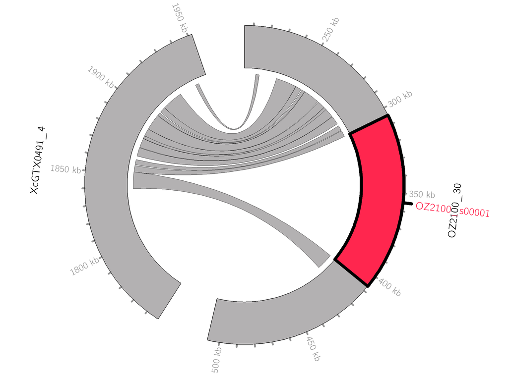

```r
knitr::include_graphics("../analysis_and_temp_files/03_starfish/pairViz/OZ2100_s00001_vs_XcGTX0491_4.png")
```

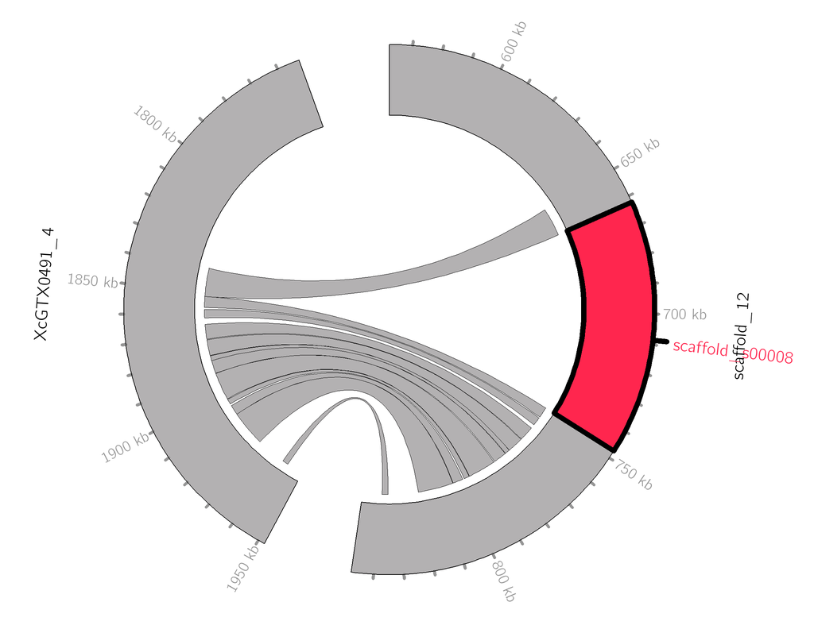

```r
knitr::include_graphics("../analysis_and_temp_files/03_starfish/pairViz/scaffold_s00008_vs_XcGTX0491_4.png")
```

- The remaining element, OZ2100_s00003 is too short to be a starship

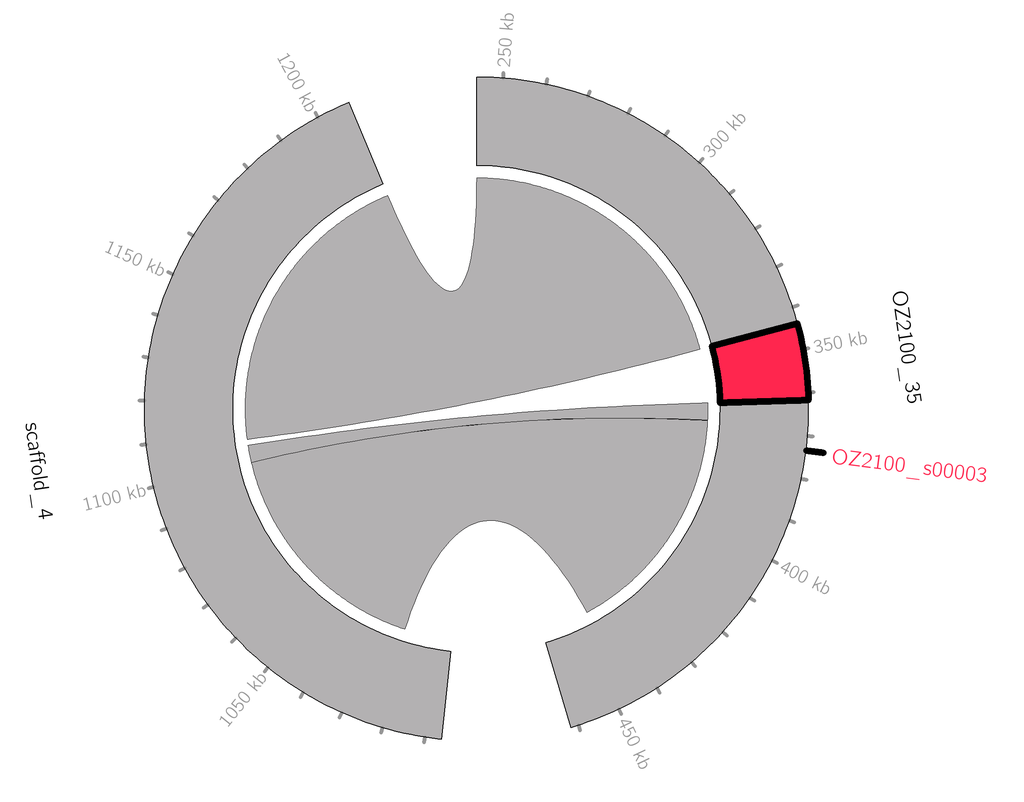

- To double-check the alignments on of navis0002-hap0001, will use starfish pair-viz with mafft instead of nucmer. This produced aligned fasta files of ~300 Kbp each (the element itself, plus 100 Kbp on each side), which was too big to load into R for visualization

```r
singularity run ../singularity/starfish.sif  starfish pair-viz -m all -t empty -T 2 -A mafft -a analysis_and_temp_files/03_starfish/ome2assembly.txt -b analysis_and_temp_files/03_starfish/elementFinder/manyxanthoria_round.elements.bed -f analysis_and_temp_files/03_starfish/elementFinder/manyxanthoria_round.flank.singleDR.stats -S analysis_and_temp_files/03_starfish/elementFinder/manyxanthoria_round.elements.named.stats -o analysis_and_temp_files/03_starfish/pairViz/
```

- Instead, imaged them using [NCBI alignment viewer](https://www.ncbi.nlm.nih.gov/projects/msaviewer). This analysis shows good alignment on both flanking regions. Here is OZ2100_s00001

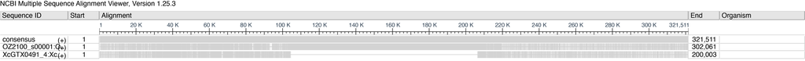

- Same for scaffold_s00008

[figure not shown]

- So far, navis0002-hap0001 seem legit!

## 6. Region finder

- create a file with tyrs that are not found in any elements. this created file `regionFinder/unaffiliated_tyrs.bed`

```r
mkdir analysis_and_temp_files/03_starfish/regionFinder
grep -f <(comm -23 <(cut -f1 analysis_and_temp_files/03_starfish/geneFinder/many_xanthorias_tyr.filt_intersect.ids | sort) <(grep -P '\tcap\t|\ttyr\t' analysis_and_temp_files/03_starfish/elementFinder/manyxanthoria_round.elements.bed | cut -f4| sort)) analysis_and_temp_files/03_starfish/geneFinder/manyxanthoria.tyr.bed > analysis_and_temp_files/03_starfish/regionFinder/unaffiliated_tyrs.bed
```

- use eggNOG annotations to detect homology

```r
singularity run ../singularity/starfish.sif /opt/conda/envs/starfish/aux/filterOG.pl -O analysis_and_temp_files/03_starfish/ann/manyxanthorias.gene2og.mcl -a 1 -c 5 -o analysis_and_temp_files/03_starfish/ann/
```

```r
singularity run ../singularity/starfish.sif starfish dereplicate -e analysis_and_temp_files/03_starfish/elementFinder/manyxanthoria_round.element.navis-hap.mcl -t analysis_and_temp_files/03_starfish/regionFinder/unaffiliated_tyrs.bed -F analysis_and_temp_files/03_starfish/elementFinder/manyxanthoria_round.elements.feat -S analysis_and_temp_files/03_starfish/elementFinder/manyxanthoria_round.elements.named.stats -O analysis_and_temp_files/03_starfish/ann/manyxanthorias.gene2og.a1.c5.txt -g analysis_and_temp_files/03_starfish/ome2gff.txt -x manyxanthoria -o analysis_and_temp_files/03_starfish/regionFinder/ --flanking 6 --mismatching 1
```

- STDOUT:
  - parsing 6 flanking OGs within 600000bp of the up and downstream boundaries of 3 elements..
  - failed to retrieve the flanking haplotypes of 0 elements with fewer than 2 OGs on at least one flank
  - grouping the flanks of the remaining 3 elements into homologous region groups, allowing for a maximum of 1 OG mismatches..
  - grouped element flanks into 2 homologous region groups, where 1 region groups have >1 element and 1 have 1
  - searching for haplotypes missing element insertions but with homology to region groups..
  - found 1 empty haplotypes distributed across 1 homologous region groups..
  - searching for fragmented haplotypes missing element insertions but with homology to known region groups..
  - found 1 fragmented haplotypes across 1 homologous region groups..
  - merging regions where >=50% of empty or frag haplotypes overlap by >=25% of their length..
  - after merging: grouped element flanks into 2 homologous region groups, where 1 region groups have >1 element and 1 have 1
  - after merging: found 1 empty haplotypes distributed across 1 homologous region groups..
  - after merging: found 1 fragmented haplotypes across 1 homologous region groups..
  - cross-referencing the coordinates of 2 element insertion sites with empty and fragmented haplotypes..
  - validated 1 insertion sites found inside empty and fragmented haplotypes
  - cross-referencing the coordinates of 16 tyrs not associated with elements with the coordinates of fragmented haplotypes..
  - found 0 tyrs inside fragmented haplotypes
  - choosing one representative element per element family at each of the 2 homologous region groups..
  - found 1 regions with at least 1 cross-referenced element-insertion site pair
  - found 1 regions with 1 element and >=1 empty/fragmented haplotype
  - found 0 regions with >1 element and >=1 empty/fragmented haplotype
  - found 0 regions with 1 element and 0 empty/fragmented haplotypes
  - found 1 regions with >1 element and 0 empty/fragmented haplotypes
- Looking inside `manyxanthoria.fog6.d600000.m1.regions.txt`, see our elements are in region0001. The flanking OGs match between them (but in reverse, since they are in opposite strands)

```r
stat8<-read.delim2("../analysis_and_temp_files/03_starfish/regionFinder/manyxanthoria.fog6.d600000.m1.regions.txt",header=T)
stat8 %>% kable(format = "html", col.names = colnames(stat8)) %>%
  kable_styling() %>%
  kableExtra::scroll_box(width = "100%", height = "200px")
```

[output not shown]

- Visualize locus

```r
mkdir analysis_and_temp_files/03_starfish/locusViz

singularity run ../singularity/starfish.sif starfish locus-viz -T 2 -m region -a analysis_and_temp_files/03_starfish/ome2assembly.txt -b analysis_and_temp_files/03_starfish/elementFinder/manyxanthoria_round.elements.bed  -x manyxanthoria -o analysis_and_temp_files/03_starfish/locusViz/ -A nucmer -r analysis_and_temp_files/03_starfish/regionFinder/manyxanthoria.fog6.d600000.m1.regions.txt -d analysis_and_temp_files/03_starfish/regionFinder/manyxanthoria.fog6.d600000.m1.dereplicated.txt -j analysis_and_temp_files/03_starfish/regionFinder/manyxanthoria.fog6.d600000.m1.haplotype_jaccard.sim  -g analysis_and_temp_files/03_starfish/ome2consolidatedGFF3.txt --tags analysis_and_temp_files/03_starfish/geneFinder/many_xanthorias_tyr.filt_intersect.ids --gc analysis_and_temp_files/03_starfish/blastdb/manyxanthorias.assemblies.gcContent_w1000.bed
```

## 7. Genes inside the elements

- What are the genes present in the elements? First, looking into GCA964656405 (that contains OZ2100_s00001) and listed all the genes in the contig OZ2100_30 in the window 304726-406787. Among the six genes, in addition to the captain, there is an NLR, DUF3723 domain protein, and a Patatin-like phospholipase (PLP), which are all common in starships. Also, there is a Methyltransferase

```r
OZ2100_s00001_genes <-read.delim2("../analysis_and_temp_files/03_starfish/ann/Xanthoria_parietina_SAMEA111342678.annotations.txt",header=T) %>%
  select(GeneID,TranscriptID,Contig,Start,Stop,Strand,InterPro) %>%
  filter(Contig == "OZ210030",Start>=304726,Stop<=406787)
OZ2100_s00001_genes$GeneID <- str_replace(OZ2100_s00001_genes$GeneID,"FUN_","XANPAOZ2100_")
OZ2100_s00001_genes$TranscriptID <- str_replace(OZ2100_s00001_genes$TranscriptID,"FUN_","XANPAOZ2100_")

OZ2100_s00001_genes %>% kable(format = "html", col.names = colnames(OZ2100_s00001_genes)) %>%
  kable_styling() %>%
  kableExtra::scroll_box(width = "100%", height = "200px")
```

GeneID

TranscriptID

Contig

Start

Stop

Strand

InterPro

XANPAOZ2100_002162

XANPAOZ2100_002162-T1

OZ210030

306501

307018

IPR021842 Protein of unknown function DUF3435

XANPAOZ2100_002163

XANPAOZ2100_002163-T1

OZ210030

361239

362028

XANPAOZ2100_002164

XANPAOZ2100_002164-T1

OZ210030

362108

363397

IPR022198 Protein of unknown function DUF3723

XANPAOZ2100_002165

XANPAOZ2100_002165-T1

OZ210030

363598

365731

IPR002641 Patatin-like phospholipase domain;IPR016035 Acyl transferase/acyl hydrolase/lysophospholipase

XANPAOZ2100_002166

XANPAOZ2100_002166-T1

OZ210030

369245

370049

IPR013216 Methyltransferase type 11;IPR029063 S-adenosyl-L-methionine-dependent methyltransferase superfamily

XANPAOZ2100_002167

XANPAOZ2100_002167-T1

OZ210030

370399

376212

IPR002110 Ankyrin repeat;IPR007111 NACHT nucleoside triphosphatase;IPR027417 P-loop containing nucleoside triphosphate hydrolase;IPR036770 Ankyrin repeat-containing domain superfamily

In the SAMEA115359166 genome, got the same set, plus two non-anottated and another proteins with ankyrin domain

```r
scaffold_s00008_genes <-read.delim2("../analysis_and_temp_files/03_starfish/ann/Xanthoria_parietina_SAMEA115359166.annotations.txt",header=T) %>%
  select(GeneID,TranscriptID,Contig,Start,Stop,Strand,InterPro) %>%
  filter(Contig == "scaffold_12",Start>=662355,Stop<=747238)

scaffold_s00008_genes$GeneID <- str_replace(scaffold_s00008_genes$GeneID,"FUN_","XANPARI20_")
scaffold_s00008_genes$TranscriptID <- str_replace(scaffold_s00008_genes$TranscriptID,"FUN_","XANPARI20_")

scaffold_s00008_genes %>% kable(format = "html", col.names = colnames(scaffold_s00008_genes)) %>%
  kable_styling() %>%
  kableExtra::scroll_box(width = "100%", height = "200px")
```

GeneID

TranscriptID

Contig

Start

Stop

Strand

InterPro

XANPARI20_008745

XANPARI20_008745-T1

scaffold_12

678924

680403

IPR002110 Ankyrin repeat;IPR036770 Ankyrin repeat-containing domain superfamily

XANPARI20_008746

XANPARI20_008746-T1

scaffold_12

686546

692778

IPR002110 Ankyrin repeat;IPR007111 NACHT nucleoside triphosphatase;IPR027417 P-loop containing nucleoside triphosphate hydrolase;IPR036770 Ankyrin repeat-containing domain superfamily

XANPARI20_008747

XANPARI20_008747-T1

scaffold_12

693128

693932

IPR013216 Methyltransferase type 11;IPR029063 S-adenosyl-L-methionine-dependent methyltransferase superfamily

XANPARI20_008748

XANPARI20_008748-T1

scaffold_12

697446

699579

IPR002641 Patatin-like phospholipase domain;IPR016035 Acyl transferase/acyl hydrolase/lysophospholipase

XANPARI20_008749

XANPARI20_008749-T1

scaffold_12

701095

702351

IPR022198 Protein of unknown function DUF3723

XANPARI20_008750

XANPARI20_008750-T1

scaffold_12

702431

703970

XANPARI20_008751

XANPARI20_008751-T1

scaffold_12

704329

704922

XANPARI20_008752

XANPARI20_008752-T1

scaffold_12

744946

745726

IPR002104 Integrase, catalytic domain;IPR011010 DNA breaking-rejoining enzyme, catalytic core;IPR013762 Integrase-like, catalytic domain superfamily;IPR021842 Protein of unknown function DUF3435

Visualized. Copied the R code produced by starfish and modiefied it to add appropriate tags to the proteins

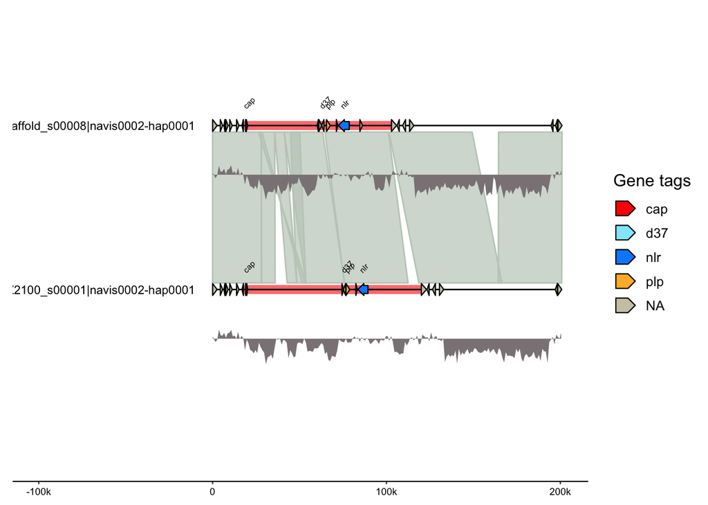

```r
library(gggenomes)
regionGenes = utils::read.table("../analysis_and_temp_files/03_starfish/locusViz//manyxanthoria.region0001.genes.config", header = T, sep = '   ')
regionSeqs = utils::read.table("../analysis_and_temp_files/03_starfish/locusViz//manyxanthoria.region0001.seqs.config", header = T, sep = ' ')
regionFeats = utils::read.table("../analysis_and_temp_files/03_starfish/locusViz//manyxanthoria.region0001.feats.config", header = T, sep = '   ')
linkFeats = read_links("../analysis_and_temp_files/03_starfish/locusViz//manyxanthoria.region0001.links.filt.tsv", format = 'blast')
regionGC <- read_bed("../analysis_and_temp_files/03_starfish/locusViz//manyxanthoria.region0001.gc.config")

#add names
regionGenes$name[regionGenes$feat_id %in% c("XANPARI20_008749-T1", "XANPAOZ2100_002164-T1")] <- "d37"
regionGenes$name[regionGenes$feat_id %in% c("XANPAOZ2100_002165-T1", "XANPARI20_008748-T1")] <- "plp"
regionGenes$name[regionGenes$feat_id %in% c("XANPAOZ2100_002167-T1", "XANPARI20_008746-T1")] <- "nlr"


widthFrac = max(regionSeqs$length) / 20000
#heightFrac = nrow(regionSeqs) / 2 # for default cases
heightFrac = nrow(regionSeqs) / 1.1 # for when OG ids are included as gene_name

align <- gggenomes(genes = regionGenes, seqs = regionSeqs, feats = regionFeats, links = linkFeats) %>% add_feats(gc=regionGC) +
  geom_link(offset = 0.04) +
  geom_bin_label(size = 3, expand_x = -100000, nudge_left = 0.05) +
  geom_feat(alpha=.6, linewidth=3, position="identity", color = "#ff0000") +
  geom_seq(linewidth = 0.5) +
  geom_gene(aes(fill=name), show.legend = T, shape = 3) + geom_wiggle(aes(z=score, group=seq_id), feats(gc), fill="lavenderblush4", offset=-.3, height=.38, bounds=c(.5,0.15,0.65)) +
  scale_fill_manual("Gene tags", values = c("cap" = "#ff0000", "tyr" = "#ff0000", "d37" = "#92e9ff", "fre" = "#b17227", "plp" = "#fdb735", "nlr" = "#048dfb"), na.value = "cornsilk3") +
  geom_gene_tag(aes(label=name), size = 2, nudge_y=0.1, check_overlap = FALSE)
align
```

#### Blasting against STARBASE: hits for NLR and PLP only

- Can we find any of the genes from our elements in starships from other fungi?
- Downloaded the complete STARBASE (both curated and non-curated starships) on 2025/03/26

```r
mkdir analysis_and_temp_files/03_starfish/search_starbase

source package d6092385-3a81-49d9-b044-8ffb85d0c446
tblastn -query analysis_and_temp_files/03_starfish/blast_genes/genes_from_OZ2100_SAMEA115359166.fa -subject data/starships_20250326_134638.fasta -outfmt 6 -evalue 1e-40 -out analysis_and_temp_files/03_starfish/search_starbase/genes_from_OZ2100_SAMEA115359166_in_starbase.out

#saved a file with the fasta headers for future use
grep ">" data/starships_20250326_134638.fasta > analysis_and_temp_files/03_starfish/search_starbase/metadata.txt
```

```r
#make a table for the starship identity
starbase_metadata <- read.delim("../analysis_and_temp_files/03_starfish/search_starbase/metadata.txt",header=F)
starbase_metadata$ID <- str_match(starbase_metadata$V1, ">(.*?)\\s\\[org")[,2]
starbase_metadata$species <- str_match(starbase_metadata$V1, "organism=(.*?)\\]\\s\\[lineage")[,2]
starbase_metadata$taxonomy <- str_match(starbase_metadata$V1, "lineage=Fungi;\\s(.*?)\\]\\s\\[location")[,2]
starbase_metadata <- starbase_metadata %>% separate_wider_delim(cols = taxonomy, delim = "; ", names = c("order", "family","genus"))


starbase_blast <- read.delim("../analysis_and_temp_files/03_starfish/search_starbase/genes_from_OZ2100_SAMEA115359166_in_starbase.out",header=F) %>%
  left_join(starbase_metadata,by=c("V2"="ID"))

starbase_blast %>% filter(V1.x=="XANPAOZ2100_002167-T1") %>%
  group_by(order) %>% summarize(hit_number = n())
```

[output not shown]

- Seems that our element cannot be said to be docoumented in the database?

## 8. Look into TEs in and around our element

### 8.1. TEs inside the starship

- List TEs inside the element in the SAMEA111342678 genome (column 6 shows score from RepeatMasker; TSTART and TEND in the final column show to which part of the TE sequence is the match)

```r
earlgrey_SAMEA111342678 <- read.delim2("../analysis_and_temp_files/02_annotate/earlgrey_data/Xp_SAMEA111342678_summaryFiles/Xp_SAMEA111342678.filteredRepeats.gff",sep="\t",skip=1,header=F)
earlgrey_SAMEA111342678$V3 <- str_replace_all(earlgrey_SAMEA111342678$V3,"Gypsy","Ty3")

earlgrey_SAMEA111342678_element <- earlgrey_SAMEA111342678 %>% filter(V1=="OZ2100_30",V4>304726,V5<406787) %>%
  mutate(length=V5-V4,
    family=str_match(V9, "ID=(.*?);")[,2])

earlgrey_SAMEA111342678_element %>% kable(format = "html", col.names = colnames(earlgrey_SAMEA111342678_element)) %>%
  kable_styling() %>%
  kableExtra::scroll_box(width = "100%", height = "200px")
```

V1

V2

V3

V4

V5

V6

V7

V8

V9

length

family

OZ2100_30

Earl_Grey

LTR/Ty3

309423

310587

9744

.

TSTART=4;TEND=1170;ID=RND-2_FAMILY-34;SHORTTE=F

1164

RND-2_FAMILY-34

OZ2100_30

Earl_Grey

LTR/Ty3

310588

310757

1476

.

TSTART=5768;TEND=5946;ID=RND-1_FAMILY-29;SHORTTE=F

169

RND-1_FAMILY-29

OZ2100_30

Earl_Grey

LTR/Ty3

310758

310832

652

.

TSTART=1160;TEND=1245;ID=RND-2_FAMILY-34;SHORTTE=T

74

RND-2_FAMILY-34

OZ2100_30

Earl_Grey

LINE/Tad1

310833

311959

9048

.

TSTART=4201;TEND=5378;ID=RND-1_FAMILY-1;SHORTTE=F

1126

RND-1_FAMILY-1

OZ2100_30

Earl_Grey

LTR/Ty3

311960

312839

7201

.

TSTART=3309;TEND=4199;ID=RND-3_FAMILY-138;SHORTTE=F

879

RND-3_FAMILY-138

OZ2100_30

Earl_Grey

LINE/Tad1

312840

314837

1588

.

TSTART=9;TEND=5367;ID=RND-1_FAMILY-1;SHORTTE=F;TEGROUP=CTG_3|RND-1_FAMILY-1|1

1997

RND-1_FAMILY-1

OZ2100_30

Earl_Grey

LTR/Copia

314838

315055

2060

.

TSTART=6211;TEND=6432;ID=RND-1_FAMILY-36;SHORTTE=F

217

RND-1_FAMILY-36

OZ2100_30

Earl_Grey

LINE/Tad1

315059

315493

3791

.

TSTART=1679;TEND=2113;ID=RND-1_FAMILY-1;SHORTTE=F

434

RND-1_FAMILY-1

OZ2100_30

Earl_Grey

LTR/Ty3

315494

322125

50401

.

TSTART=1;TEND=6686;ID=RND-1_FAMILY-7;SHORTTE=F

6631

RND-1_FAMILY-7

OZ2100_30

Earl_Grey

LINE/Tad1

322126

322805

5515

.

TSTART=2111;TEND=2790;ID=RND-1_FAMILY-1;SHORTTE=F

679

RND-1_FAMILY-1

OZ2100_30

Earl_Grey

LTR/Ty3

322806

329708

55834

.

TSTART=1;TEND=6968;ID=RND-1_FAMILY-66;SHORTTE=F

6902

RND-1_FAMILY-66

OZ2100_30

Earl_Grey

LINE/Tad1

329709

335218

20193

.

TSTART=2176;TEND=5378;ID=RND-1_FAMILY-1;SHORTTE=F;TEGROUP=CTG_3|RND-1_FAMILY-1|2

5509

RND-1_FAMILY-1

OZ2100_30

Earl_Grey

LINE/Tad1

335219

340534

46599

.

TSTART=7;TEND=5323;ID=RND-1_FAMILY-1;SHORTTE=F

5315

RND-1_FAMILY-1

OZ2100_30

Earl_Grey

LINE/Tad1

340568

342750

16929

.

TSTART=6;TEND=2188;ID=RND-1_FAMILY-1;SHORTTE=F

2182

RND-1_FAMILY-1

OZ2100_30

Earl_Grey

LTR/Ty3

342773

343032

2217

.

TSTART=4176;TEND=4446;ID=RND-3_FAMILY-139;SHORTTE=F

259

RND-3_FAMILY-139

OZ2100_30

Earl_Grey

Unknown

343033

343102

354

.

TSTART=5;TEND=152;ID=RND-1_FAMILY-60;SHORTTE=F

69

RND-1_FAMILY-60

OZ2100_30

Earl_Grey

Unknown

343103

343597

2469

.

TSTART=1;TEND=540;ID=RND-1_FAMILY-64;SHORTTE=F

494

RND-1_FAMILY-64

OZ2100_30

Earl_Grey

LTR/Ty3

343598

344171

4429

.

TSTART=4442;TEND=5024;ID=RND-3_FAMILY-139;SHORTTE=F

573

RND-3_FAMILY-139

OZ2100_30

Earl_Grey

LINE/Tad1

344172

349420

45199

.

TSTART=75;TEND=5379;ID=RND-1_FAMILY-1;SHORTTE=F

5248

RND-1_FAMILY-1

OZ2100_30

Earl_Grey

Unknown

349421

351065

14725

.

TSTART=1052;TEND=2699;ID=RND-1_FAMILY-20;SHORTTE=F

1644

RND-1_FAMILY-20

OZ2100_30

Earl_Grey

LTR/Ty3

351066

351646

4656

.

TSTART=5007;TEND=5590;ID=RND-3_FAMILY-139;SHORTTE=F

580

RND-3_FAMILY-139

OZ2100_30

Earl_Grey

LTR/Ty3

351647

358331

52605

.

TSTART=2;TEND=6678;ID=RND-1_FAMILY-67;SHORTTE=F

6684

RND-1_FAMILY-67

OZ2100_30

Earl_Grey

LTR/Ty3

358332

358999

5371

.

TSTART=5581;TEND=6248;ID=RND-3_FAMILY-139;SHORTTE=F

667

RND-3_FAMILY-139

OZ2100_30

Earl_Grey

Simple_repeat

360131

360166

12

.

TSTART=1;TEND=36;ID=(GTTG)N;SHORTTE=F

35

(GTTG)N

OZ2100_30

Earl_Grey

Simple_repeat

366834

366871

14

.

TSTART=1;TEND=38;ID=(ATTGATA)N;SHORTTE=F

37

(ATTGATA)N

OZ2100_30

Earl_Grey

Simple_repeat

371686

371721

14

.

TSTART=1;TEND=36;ID=(ATC)N;SHORTTE=F

35

(ATC)N

OZ2100_30

Earl_Grey

Simple_repeat

377854

377881

15

.

TSTART=1;TEND=30;ID=(TTGAT)N;SHORTTE=F

27

(TTGAT)N

OZ2100_30

Earl_Grey

Unknown

377915

377952

261

.

TSTART=1;TEND=38;ID=RND-3_FAMILY-840;SHORTTE=T

37

RND-3_FAMILY-840

OZ2100_30

Earl_Grey

LINE/I

386500

388498

9426

.

TSTART=3529;TEND=5510;ID=RND-1_FAMILY-32;SHORTTE=F

1998

RND-1_FAMILY-32

OZ2100_30

Earl_Grey

Low_complexity

388854

388893

14

.

TSTART=1;TEND=41;ID=GA-RICH;SHORTTE=F

39

GA-RICH

OZ2100_30

Earl_Grey

LTR/Ty3

391152

397396

53427

.

TSTART=4;TEND=6249;ID=RND-3_FAMILY-139;SHORTTE=F

6244

RND-3_FAMILY-139

OZ2100_30

Earl_Grey

Simple_repeat

397572

397595

14

.

TSTART=1;TEND=23;ID=(CCA)N;SHORTTE=F

23

(CCA)N

OZ2100_30

Earl_Grey

LTR/Ty3

399692

405475

42724

.

TSTART=1;TEND=5946;ID=RND-1_FAMILY-29;SHORTTE=F;LTRGROUP=CTG_3_G2

5783

RND-1_FAMILY-29

On the family level, have one dominant (RND-1_FAMILY-1; LINE/Tad1). The sequence for this family is 5334 bp, so the starship contains two almost complete sequences and several fragments

```r
earlgrey_SAMEA111342678_element %>% group_by(family,V3) %>% summarize(total_bp=sum(length)) %>% arrange(desc(total_bp)) %>% head(20)
```

```
## # A tibble: 20 × 3
## # Groups:   family [20]
##    family           V3             total_bp
##    <chr>            <chr>             <int>
##  1 RND-1_FAMILY-1   LINE/Tad1         22490
##  2 RND-3_FAMILY-139 LTR/Ty3            8323
##  3 RND-1_FAMILY-66  LTR/Ty3            6902
##  4 RND-1_FAMILY-67  LTR/Ty3            6684
##  5 RND-1_FAMILY-7   LTR/Ty3            6631
##  6 RND-1_FAMILY-29  LTR/Ty3            5952
##  7 RND-1_FAMILY-32  LINE/I             1998
##  8 RND-1_FAMILY-20  Unknown            1644
##  9 RND-2_FAMILY-34  LTR/Ty3            1238
## 10 RND-3_FAMILY-138 LTR/Ty3             879
## 11 RND-1_FAMILY-64  Unknown             494
## 12 RND-1_FAMILY-36  LTR/Copia           217
## 13 RND-1_FAMILY-60  Unknown              69
## 14 GA-RICH          Low_complexity       39
## 15 (ATTGATA)N       Simple_repeat        37
## 16 RND-3_FAMILY-840 Unknown              37
## 17 (ATC)N           Simple_repeat        35
## 18 (GTTG)N          Simple_repeat        35
## 19 (TTGAT)N         Simple_repeat        27
## 20 (CCA)N           Simple_repeat        23
```

- But over superfamilies, LTR/Ty3 has higher coverage

```r
earlgrey_SAMEA111342678_element %>% group_by(V3) %>% summarize(total_bp=sum(length)) %>% arrange(desc(total_bp)) %>% head(20)
```

```
## # A tibble: 7 × 2
##   V3             total_bp
##   <chr>             <int>
## 1 LTR/Ty3           36609
## 2 LINE/Tad1         22490
## 3 Unknown            2244
## 4 LINE/I             1998
## 5 LTR/Copia           217
## 6 Simple_repeat       157
## 7 Low_complexity       39
```

- Same for SAMEA115359166

```r
earlgrey_SAMEA115359166 <- read.delim2("../analysis_and_temp_files/02_annotate/earlgrey_data/Xp_SAMEA115359166_summaryFiles/Xp_SAMEA115359166.filteredRepeats.gff",sep="\t",skip=1,header=F)
earlgrey_SAMEA115359166$V3 <- str_replace_all(earlgrey_SAMEA115359166$V3,"Gypsy","Ty3")
earlgrey_SAMEA115359166_element <- earlgrey_SAMEA115359166 %>% filter(V1=="scaffold_12",V4>662355,V5<747238) %>%
  mutate(length=V5-V4,
    family=str_match(V9, "ID=(.*?);")[,2])

earlgrey_SAMEA115359166_element %>% kable(format = "html", col.names = colnames(earlgrey_SAMEA111342678_element)) %>%
  kable_styling() %>%
  kableExtra::scroll_box(width = "100%", height = "200px")
```

V1

V2

V3

V4

V5

V6

V7

V8

V9

length

family

scaffold_12

Earl_Grey

Simple_repeat

665634

665657

14

.

TSTART=1;TEND=23;ID=(GGT)N;SHORTTE=F

23

(GGT)N

scaffold_12

Earl_Grey

LTR/Ty3

665831

672077

53929

.

TSTART=3;TEND=6251;ID=RND-2_FAMILY-14;SHORTTE=F

6246

RND-2_FAMILY-14

scaffold_12

Earl_Grey

Simple_repeat

674335

674374

14

.

TSTART=1;TEND=41;ID=(CCTCT)N;SHORTTE=F

39

(CCTCT)N

scaffold_12

Earl_Grey

LINE/Tad1

674730

676728

9520

.

TSTART=2108;TEND=4089;ID=RND-1_FAMILY-82;SHORTTE=F

1998

RND-1_FAMILY-82

scaffold_12

Earl_Grey

Simple_repeat

685296

685323

15

.

TSTART=1;TEND=30;ID=(ATCAA)N;SHORTTE=F

27

(ATCAA)N

scaffold_12

Earl_Grey

Simple_repeat

691456

691491

14

.

TSTART=1;TEND=36;ID=(GAT)N;SHORTTE=F

35

(GAT)N

scaffold_12

Earl_Grey

Unknown

696005

696098

261

.

TSTART=442;TEND=535;ID=RND-1_FAMILY-8;SHORTTE=T

93

RND-1_FAMILY-8

scaffold_12

Earl_Grey

Simple_repeat

696306

696343

14

.

TSTART=1;TEND=38;ID=(AATTATC)N;SHORTTE=F

37

(AATTATC)N

scaffold_12

Earl_Grey

Simple_repeat

704293

704328

12

.

TSTART=1;TEND=36;ID=(CAAC)N;SHORTTE=F

35

(CAAC)N

scaffold_12

Earl_Grey

LTR/Ty3

705458

706125

5373

.

TSTART=5583;TEND=6250;ID=RND-2_FAMILY-14;SHORTTE=F

667

RND-2_FAMILY-14

scaffold_12

Earl_Grey

LTR/Ty3

706126

712814

53453

.

TSTART=1;TEND=6713;ID=RND-1_FAMILY-57;SHORTTE=F

6688

RND-1_FAMILY-57

scaffold_12

Earl_Grey

LTR/Ty3

712815

713392

4671

.

TSTART=5007;TEND=5584;ID=RND-2_FAMILY-14;SHORTTE=F

577

RND-2_FAMILY-14

scaffold_12

Earl_Grey

LINE/Tad1

713393

715038

14766

.

TSTART=171;TEND=1818;ID=RND-1_FAMILY-2;SHORTTE=F

1645

RND-1_FAMILY-2

scaffold_12

Earl_Grey

LINE/Tad1

715039

720287

45973

.

TSTART=76;TEND=5333;ID=RND-1_FAMILY-1;SHORTTE=F

5248

RND-1_FAMILY-1

scaffold_12

Earl_Grey

LTR/Ty3

720288

720861

4460

.

TSTART=4442;TEND=5024;ID=RND-2_FAMILY-14;SHORTTE=F

573

RND-2_FAMILY-14

scaffold_12

Earl_Grey

Unknown

720862

721427

2989

.

TSTART=9;TEND=605;ID=RND-1_FAMILY-63;SHORTTE=F

565

RND-1_FAMILY-63

scaffold_12

Earl_Grey

LTR/Ty3

721428

721686

2251

.

TSTART=4176;TEND=4446;ID=RND-2_FAMILY-14;SHORTTE=F

258

RND-2_FAMILY-14

scaffold_12

Earl_Grey

LINE/Tad1

721709

730067

40648

.

TSTART=7;TEND=5324;ID=RND-1_FAMILY-1;SHORTTE=F;TEGROUP=CTG_12|RND-1_FAMILY-1|1

8358

RND-1_FAMILY-1

scaffold_12

Earl_Grey

LTR/Ty3

730068

736697

55331

.

TSTART=2;TEND=6649;ID=RND-1_FAMILY-24;SHORTTE=F

6629

RND-1_FAMILY-24

scaffold_12

Earl_Grey

LINE/Tad1

736698

739125

17107

.

TSTART=10;TEND=5365;ID=RND-1_FAMILY-1;SHORTTE=F;TEGROUP=CTG_12|RND-1_FAMILY-1|2

2427

RND-1_FAMILY-1

scaffold_12

Earl_Grey

LTR/Ty3

739126

740005

6922

.

TSTART=3309;TEND=4199;ID=RND-2_FAMILY-14;SHORTTE=F

879

RND-2_FAMILY-14

scaffold_12

Earl_Grey

LINE/Tad1

740006

741126

8800

.

TSTART=4202;TEND=5328;ID=RND-1_FAMILY-1;SHORTTE=F

1120

RND-1_FAMILY-1

scaffold_12

Earl_Grey

LTR/Ty3

741127

741207

620

.

TSTART=1160;TEND=1245;ID=RND-2_FAMILY-14;SHORTTE=T

80

RND-2_FAMILY-14

scaffold_12

Earl_Grey

LTR/Ty3

741208

741376

1445

.

TSTART=5673;TEND=5845;ID=RND-3_FAMILY-123;SHORTTE=F

168

RND-3_FAMILY-123

scaffold_12

Earl_Grey

LTR/Ty3

741377

742541

9384

.

TSTART=4;TEND=1170;ID=RND-2_FAMILY-14;SHORTTE=F

1164

RND-2_FAMILY-14

Same dominant family (RND-1_FAMILY-1; LINE/Tad1), aligns well to RND-1_FAMILY-1 from SAMEA111342678 (98.2% identical over 100% query)

```r
earlgrey_SAMEA115359166_element %>% group_by(family,V3) %>% summarize(total_bp=sum(length)) %>% arrange(desc(total_bp)) %>% head(20)
```

```
## # A tibble: 15 × 3
## # Groups:   family [15]
##    family           V3            total_bp
##    <chr>            <chr>            <int>
##  1 RND-1_FAMILY-1   LINE/Tad1        17153
##  2 RND-2_FAMILY-14  LTR/Ty3          10444
##  3 RND-1_FAMILY-57  LTR/Ty3           6688
##  4 RND-1_FAMILY-24  LTR/Ty3           6629
##  5 RND-1_FAMILY-82  LINE/Tad1         1998
##  6 RND-1_FAMILY-2   LINE/Tad1         1645
##  7 RND-1_FAMILY-63  Unknown            565
##  8 RND-3_FAMILY-123 LTR/Ty3            168
##  9 RND-1_FAMILY-8   Unknown             93
## 10 (CCTCT)N         Simple_repeat       39
## 11 (AATTATC)N       Simple_repeat       37
## 12 (CAAC)N          Simple_repeat       35
## 13 (GAT)N           Simple_repeat       35
## 14 (ATCAA)N         Simple_repeat       27
## 15 (GGT)N           Simple_repeat       23
```

- Over superfamilies, LTR/Ty3 has higher coverage, but not by much

```r
earlgrey_SAMEA115359166_element %>% group_by(V3) %>% summarize(total_bp=sum(length)) %>% arrange(desc(total_bp)) %>% head(20)
```

```
## # A tibble: 4 × 2
##   V3            total_bp
##   <chr>            <int>
## 1 LTR/Ty3          23929
## 2 LINE/Tad1        20796
## 3 Unknown            658
## 4 Simple_repeat      196
```

- Total repeat cov in the element is 63754 in SAMEA111342678 and 45579 in SAMEA115359166, which corresponds to 0.6247 and 0.537
- Most of the difference in the starship length between these two genomes comes from repeats and non-repeat portions have similar lengths: 38308 in SAMEA111342678 (compared to 102062 bp total length) and 39305 SAMEA115359166 (84884 bp in total)

### 8.2. TEs in the LRAR right downstream of the starship

- Same Ty3 and Tad1 dominate the LRAR in SAMEA111342678

```r
earlgrey_SAMEA111342678_lrar <- earlgrey_SAMEA111342678 %>% filter(V1=="OZ2100_30",V4>419500,V5<480500) %>%
  mutate(length=V5-V4,
    family=str_match(V9, "ID=(.*?);")[,2])

earlgrey_SAMEA111342678_lrar %>% kable(format = "html", col.names = colnames(earlgrey_SAMEA111342678_element)) %>%
  kable_styling() %>%
  kableExtra::scroll_box(width = "100%", height = "200px")
```

V1

V2

V3

V4

V5

V6

V7

V8

V9

length

family

OZ2100_30

Earl_Grey

LTR/Ty3

420165

420831

1768

.

TSTART=758;TEND=1241;ID=RND-1_FAMILY-58;SHORTTE=F

666

RND-1_FAMILY-58

OZ2100_30

Earl_Grey

LTR/Ty3

421167

421566

2710

.

TSTART=5295;TEND=5694;ID=RND-1_FAMILY-67;SHORTTE=F

399

RND-1_FAMILY-67

OZ2100_30

Earl_Grey

LINE/Tad1

421682

427042

44476

.

TSTART=4;TEND=5364;ID=RND-1_FAMILY-57;SHORTTE=F

5360

RND-1_FAMILY-57

OZ2100_30

Earl_Grey

Simple_repeat

427290

427367

16

.

TSTART=1;TEND=75;ID=(TTTATA)N;SHORTTE=F

77

(TTTATA)N

OZ2100_30

Earl_Grey

LINE/Tad1

427803

428546

6266

.

TSTART=4581;TEND=5324;ID=RND-1_FAMILY-1;SHORTTE=F

743

RND-1_FAMILY-1

OZ2100_30

Earl_Grey

LINE/Tad1

430054

432542

20682

.

TSTART=19;TEND=2507;ID=RND-1_FAMILY-48;SHORTTE=F

2488

RND-1_FAMILY-48

OZ2100_30

Earl_Grey

LTR/Ty3

432550

439280

38663

.

TSTART=1;TEND=5687;ID=RND-1_FAMILY-7;SHORTTE=F

6730

RND-1_FAMILY-7

OZ2100_30

Earl_Grey

LINE/Tad1

439281

442523

26823

.

TSTART=2503;TEND=5742;ID=RND-1_FAMILY-48;SHORTTE=F

3242

RND-1_FAMILY-48

OZ2100_30

Earl_Grey

LTR/Ty3

442766

442871

38557

.

TSTART=148;TEND=255;ID=RND-1_FAMILY-22;SHORTTE=F

105

RND-1_FAMILY-22

OZ2100_30

Earl_Grey

Unknown

442872

443043

344

.

TSTART=124;TEND=289;ID=RND-1_FAMILY-46;SHORTTE=F

171

RND-1_FAMILY-46

OZ2100_30

Earl_Grey

LTR/Ty3

443044

449494

38557

.

TSTART=256;TEND=6876;ID=RND-1_FAMILY-22;SHORTTE=F

6450

RND-1_FAMILY-22

OZ2100_30

Earl_Grey

Simple_repeat

449546

449580

16

.

TSTART=1;TEND=34;ID=(ATTAAG)N;SHORTTE=F

34

(ATTAAG)N

OZ2100_30

Earl_Grey

LINE/Tad1

451152

453264

17822

.

TSTART=3215;TEND=5332;ID=RND-1_FAMILY-1;SHORTTE=F

2112

RND-1_FAMILY-1

OZ2100_30

Earl_Grey

LTR/Ty3

454845

455019

318

.

TSTART=3018;TEND=3192;ID=RND-2_FAMILY-86;SHORTTE=F

174

RND-2_FAMILY-86

OZ2100_30

Earl_Grey

LTR/Ty3

455023

455108

756

.

TSTART=3114;TEND=3200;ID=RND-1_FAMILY-29;SHORTTE=T

85

RND-1_FAMILY-29

OZ2100_30

Earl_Grey

LINE/Tad1

455109

460833

47691

.

TSTART=1;TEND=5728;ID=RND-1_FAMILY-48;SHORTTE=F

5724

RND-1_FAMILY-48

OZ2100_30

Earl_Grey

LINE/Tad1

461129

464234

25985

.

TSTART=2219;TEND=5324;ID=RND-1_FAMILY-1;SHORTTE=F

3105

RND-1_FAMILY-1

OZ2100_30

Earl_Grey

LTR/Ty3

464465

464521

262

.

TSTART=3867;TEND=3923;ID=RND-1_FAMILY-66;SHORTTE=T

56

RND-1_FAMILY-66

OZ2100_30

Earl_Grey

LINE/Tad1

466110

471853

48441

.

TSTART=4;TEND=5745;ID=RND-1_FAMILY-48;SHORTTE=F

5743

RND-1_FAMILY-48

OZ2100_30

Earl_Grey

LINE/Tad1

471864

471907

311

.

TSTART=2069;TEND=2112;ID=RND-1_FAMILY-57;SHORTTE=T

43

RND-1_FAMILY-57

OZ2100_30

Earl_Grey

Simple_repeat

472058

472080

14

.

TSTART=1;TEND=24;ID=(TAG)N;SHORTTE=F

22

(TAG)N

OZ2100_30

Earl_Grey

LTR/Copia

472339

474752

17571

.

TSTART=1804;TEND=4215;ID=RND-1_FAMILY-37;SHORTTE=F

2413

RND-1_FAMILY-37

OZ2100_30

Earl_Grey

LINE/Tad1

476215

479392

26480

.

TSTART=2154;TEND=5334;ID=RND-1_FAMILY-1;SHORTTE=F

3177

RND-1_FAMILY-1

Same Ty3 and Tad1 dominate the LRAR in SAMEA115359166

```r
earlgrey_SAMEA115359166_lrar <- earlgrey_SAMEA115359166 %>% filter(V1=="scaffold_12",V4>602500,V5<649500) %>%
  mutate(length=V5-V4,
    family=str_match(V9, "ID=(.*?);")[,2])

earlgrey_SAMEA115359166_lrar %>% kable(format = "html", col.names = colnames(earlgrey_SAMEA111342678_element)) %>%
  kable_styling() %>%
  kableExtra::scroll_box(width = "100%", height = "200px")
```

V1

V2

V3

V4

V5

V6

V7

V8

V9

length

family

scaffold_12

Earl_Grey

LINE/Tad1

605615

606289

5458

.

TSTART=4654;TEND=5328;ID=RND-1_FAMILY-1;SHORTTE=F

674

RND-1_FAMILY-1

scaffold_12

Earl_Grey

LINE/Tad1

607905

609246

10765

.

TSTART=1830;TEND=3171;ID=RND-1_FAMILY-2;SHORTTE=F

1341

RND-1_FAMILY-2

scaffold_12

Earl_Grey

Simple_repeat

610835

610856

13

.

TSTART=1;TEND=22;ID=(TTA)N;SHORTTE=F

21

(TTA)N

scaffold_12

Earl_Grey

LINE/Tad1

611779

613488

14026

.

TSTART=107;TEND=1816;ID=RND-1_FAMILY-2;SHORTTE=F

1709

RND-1_FAMILY-2

scaffold_12

Earl_Grey

LINE/Tad1

613489

617968

36007

.

TSTART=850;TEND=5329;ID=RND-1_FAMILY-1;SHORTTE=F

4479

RND-1_FAMILY-1

scaffold_12

Earl_Grey

Simple_repeat

619538

619572

19

.

TSTART=1;TEND=35;ID=(TAAATC)N;SHORTTE=F

34

(TAAATC)N

scaffold_12

Earl_Grey

LTR/Ty3

619624

626376

35842

.

TSTART=2;TEND=6860;ID=RND-1_FAMILY-60;SHORTTE=F

6752

RND-1_FAMILY-60

scaffold_12

Earl_Grey

LINE/Tad1

626635

629861

26971

.

TSTART=2496;TEND=5722;ID=RND-1_FAMILY-43;SHORTTE=F

3226

RND-1_FAMILY-43

scaffold_12

Earl_Grey

LTR/Ty3

629919

630088

410

.

TSTART=2054;TEND=2241;ID=RND-1_FAMILY-92;SHORTTE=T;TEGROUP=CTG_12|RND-1_FAMILY-92|1

169

RND-1_FAMILY-92

scaffold_12

Earl_Grey

LTR/Ty3

630089

636593

38015

.

TSTART=1;TEND=5680;ID=RND-1_FAMILY-57;SHORTTE=F

6504

RND-1_FAMILY-57

scaffold_12

Earl_Grey

LINE/Tad1

636600

639088

20755

.

TSTART=12;TEND=2500;ID=RND-1_FAMILY-43;SHORTTE=F

2488

RND-1_FAMILY-43

scaffold_12

Earl_Grey

LINE/Tad1

640596

641339

6341

.

TSTART=4582;TEND=5325;ID=RND-1_FAMILY-1;SHORTTE=F

743

RND-1_FAMILY-1

scaffold_12

Earl_Grey

Simple_repeat

641776

641809

16

.

TSTART=1;TEND=35;ID=(AATATT)N;SHORTTE=F

33

(AATATT)N

scaffold_12

Earl_Grey

LINE/Tad1

642100

647461

44825

.

TSTART=1;TEND=5362;ID=RND-1_FAMILY-75;SHORTTE=F

5361

RND-1_FAMILY-75

scaffold_12

Earl_Grey

LTR/Ty3

647576

648961

8509

.

TSTART=2062;TEND=3448;ID=RND-1_FAMILY-97;SHORTTE=F

1385

RND-1_FAMILY-97

In X.calcicola, have some LTR/Copia and LTR/Ty3 too, but plurality of identified entries (29 out of 71) are classified as unknown

```r
earlgrey_GTX0491 <- read.delim2("../analysis_and_temp_files/02_annotate/earlgrey_data/Xc_GTX0491_summaryFiles/Xc_GTX0491.filteredRepeats.gff",sep="\t",skip=1,header=F)
earlgrey_GTX0491$V3 <- str_replace_all(earlgrey_GTX0491$V3,"Gypsy","Ty3")

earlgrey_GTX0491_lrar <- earlgrey_GTX0491 %>% filter(V1=="XcGTX0491_4",V4>1739500,V5<1839000) %>%
  mutate(length=V5-V4,
    family=str_match(V9, "ID=(.*?);")[,2])

earlgrey_GTX0491_lrar %>% kable(format = "html", col.names = colnames(earlgrey_GTX0491_lrar)) %>%
  kable_styling() %>%
  kableExtra::scroll_box(width = "100%", height = "200px")
```

V1

V2

V3

V4

V5

V6

V7

V8

V9

length

family

XcGTX0491_4

Earl_Grey

Unknown

1739767

1739833

317

.

TSTART=293;TEND=355;ID=RND-1_FAMILY-50;SHORTTE=T

66

RND-1_FAMILY-50

XcGTX0491_4

Earl_Grey

Unknown

1740309

1740452

995

.

TSTART=1;TEND=144;ID=RND-1_FAMILY-130;SHORTTE=F

143

RND-1_FAMILY-130

XcGTX0491_4

Earl_Grey

Unknown

1741416

1742206

4235

.

TSTART=11;TEND=863;ID=RND-1_FAMILY-150;SHORTTE=F

790

RND-1_FAMILY-150

XcGTX0491_4

Earl_Grey

LTR/Ty3

1742207

1742349

664

.

TSTART=7653;TEND=7796;ID=RND-1_FAMILY-203;SHORTTE=F

142

RND-1_FAMILY-203

XcGTX0491_4

Earl_Grey

SINE/B2

1742413

1742575

349

.

TSTART=2;TEND=168;ID=RND-1_FAMILY-121;SHORTTE=F

162

RND-1_FAMILY-121

XcGTX0491_4

Earl_Grey

LTR/Ty3

1742598

1743858

3034

.

TSTART=6138;TEND=7384;ID=RND-2_FAMILY-17;SHORTTE=F

1260

RND-2_FAMILY-17

XcGTX0491_4

Earl_Grey

LTR/Ty3

1743865

1751946

62971

.

TSTART=2;TEND=8082;ID=RND-1_FAMILY-203;SHORTTE=F

8081

RND-1_FAMILY-203

XcGTX0491_4

Earl_Grey

LTR/Ty3

1751949

1753350

5702

.

TSTART=4693;TEND=6127;ID=RND-2_FAMILY-17;SHORTTE=F

1401

RND-2_FAMILY-17

XcGTX0491_4

Earl_Grey

Unknown

1753351

1754085

6206

.

TSTART=1;TEND=760;ID=RND-1_FAMILY-17;SHORTTE=F

734

RND-1_FAMILY-17

XcGTX0491_4

Earl_Grey

LTR/Ty3

1754086

1754167

507

.

TSTART=4680;TEND=4763;ID=RND-1_FAMILY-203;SHORTTE=T

81

RND-1_FAMILY-203

XcGTX0491_4

Earl_Grey

Simple_repeat

1754693

1754722

15

.

TSTART=1;TEND=31;ID=(TA)N;SHORTTE=F

29

(TA)N

XcGTX0491_4

Earl_Grey

Simple_repeat

1754859

1754902

11

.

TSTART=1;TEND=44;ID=(TACTCT)N;SHORTTE=F

43

(TACTCT)N

XcGTX0491_4

Earl_Grey

Simple_repeat

1756355

1756378

12

.

TSTART=1;TEND=24;ID=(TTA)N;SHORTTE=F

23

(TTA)N

XcGTX0491_4

Earl_Grey

LTR/Ty3

1756490

1758235

13968

.

TSTART=5642;TEND=7407;ID=RND-1_FAMILY-147;SHORTTE=F

1745

RND-1_FAMILY-147

XcGTX0491_4

Earl_Grey

LTR/Ty3

1758236

1764882

48980

.

TSTART=137;TEND=6716;ID=RND-1_FAMILY-155;SHORTTE=F

6646

RND-1_FAMILY-155

XcGTX0491_4

Earl_Grey

LTR/Ty3

1764883

1770422

41434

.

TSTART=22;TEND=5642;ID=RND-1_FAMILY-147;SHORTTE=F

5539

RND-1_FAMILY-147

XcGTX0491_4

Earl_Grey

LTR/Ty3

1770439

1773908

14728

.

TSTART=1196;TEND=4680;ID=RND-1_FAMILY-203;SHORTTE=F

3469

RND-1_FAMILY-203

XcGTX0491_4

Earl_Grey

Simple_repeat

1774359

1774400

35

.

TSTART=1;TEND=42;ID=(TATTATATAT)N;SHORTTE=F

41

(TATTATATAT)N

XcGTX0491_4

Earl_Grey

Unknown

1774412

1775598

8611

.

TSTART=22;TEND=1250;ID=RND-1_FAMILY-29;SHORTTE=F

1186

RND-1_FAMILY-29

XcGTX0491_4

Earl_Grey

Simple_repeat

1776719

1776769

15

.

TSTART=1;TEND=50;ID=(TA)N;SHORTTE=F

50

(TA)N

XcGTX0491_4

Earl_Grey

Unknown

1776820

1778016

9019

.

TSTART=16;TEND=1238;ID=RND-1_FAMILY-29;SHORTTE=F

1196

RND-1_FAMILY-29

XcGTX0491_4

Earl_Grey

Simple_repeat

1778065

1778140

17

.

TSTART=1;TEND=75;ID=(TAAT)N;SHORTTE=F

75

(TAAT)N

XcGTX0491_4

Earl_Grey

Simple_repeat

1778529

1778566

14

.

TSTART=1;TEND=39;ID=(TTTAC)N;SHORTTE=F

37

(TTTAC)N

XcGTX0491_4

Earl_Grey

Simple_repeat

1779286

1779341

11

.

TSTART=1;TEND=56;ID=(ATTTAT)N;SHORTTE=F

55

(ATTTAT)N

XcGTX0491_4

Earl_Grey

Unknown

1779431

1779977

4302

.

TSTART=32;TEND=580;ID=RND-1_FAMILY-184;SHORTTE=F

546

RND-1_FAMILY-184

XcGTX0491_4

Earl_Grey

Simple_repeat

1780001

1780042

14

.

TSTART=1;TEND=39;ID=(ATTTA)N;SHORTTE=F

41

(ATTTA)N

XcGTX0491_4

Earl_Grey

Simple_repeat

1782322

1782367

13

.

TSTART=1;TEND=48;ID=(CTTTAT)N;SHORTTE=F

45

(CTTTAT)N

XcGTX0491_4

Earl_Grey

Unknown

1782993

1783123

315

.

TSTART=4448;TEND=4579;ID=RND-1_FAMILY-115;SHORTTE=F

130

RND-1_FAMILY-115

XcGTX0491_4

Earl_Grey

Unknown

1783131

1784037

322

.

TSTART=517;TEND=1432;ID=RND-1_FAMILY-55;SHORTTE=F

906

RND-1_FAMILY-55

XcGTX0491_4

Earl_Grey

Simple_repeat

1784107

1784140

14

.

TSTART=1;TEND=33;ID=(TAA)N;SHORTTE=F

33

(TAA)N

XcGTX0491_4

Earl_Grey

Unknown

1784260

1785123

378

.

TSTART=517;TEND=1210;ID=RND-1_FAMILY-55;SHORTTE=F

863

RND-1_FAMILY-55

XcGTX0491_4

Earl_Grey

Unknown

1785331

1785433

242

.

TSTART=4448;TEND=4551;ID=RND-1_FAMILY-115;SHORTTE=F

102

RND-1_FAMILY-115

XcGTX0491_4

Earl_Grey

Simple_repeat

1786336

1786417

17

.

TSTART=1;TEND=84;ID=(ATTT)N;SHORTTE=F

81

(ATTT)N

XcGTX0491_4

Earl_Grey

Simple_repeat

1787992

1788034

15

.

TSTART=1;TEND=43;ID=(TTA)N;SHORTTE=F

42

(TTA)N

XcGTX0491_4

Earl_Grey

Simple_repeat

1789390

1789505

28

.

TSTART=1;TEND=115;ID=(TTAT)N;SHORTTE=F

115

(TTAT)N

XcGTX0491_4

Earl_Grey

Simple_repeat

1789864

1789914

22

.

TSTART=1;TEND=52;ID=(TA)N;SHORTTE=F

50

(TA)N

XcGTX0491_4

Earl_Grey

Simple_repeat

1790206

1790245

27

.

TSTART=1;TEND=39;ID=(CTAATATAT)N;SHORTTE=F

39

(CTAATATAT)N

XcGTX0491_4

Earl_Grey

Unknown

1791299

1791868

4098

.

TSTART=10;TEND=585;ID=RND-1_FAMILY-184;SHORTTE=F

569

RND-1_FAMILY-184

XcGTX0491_4

Earl_Grey

LTR/Ty3

1792081

1795504

13417

.

TSTART=1197;TEND=4681;ID=RND-2_FAMILY-17;SHORTTE=F

3423

RND-2_FAMILY-17

XcGTX0491_4

Earl_Grey

Unknown

1795608

1799136

26527

.

TSTART=4;TEND=3528;ID=RND-1_FAMILY-118;SHORTTE=F

3528

RND-1_FAMILY-118

XcGTX0491_4

Earl_Grey

Unknown

1799276

1800105

5339

.

TSTART=9;TEND=874;ID=RND-1_FAMILY-11;SHORTTE=F

829

RND-1_FAMILY-11

XcGTX0491_4

Earl_Grey

Unknown

1800106

1805086

25500

.

TSTART=1;TEND=5100;ID=RND-1_FAMILY-55;SHORTTE=F;TEGROUP=CTG_4|RND-1_FAMILY-55|1

4980

RND-1_FAMILY-55

XcGTX0491_4

Earl_Grey

Unknown

1805087

1805804

4992

.

TSTART=7;TEND=795;ID=RND-1_FAMILY-158;SHORTTE=F

717

RND-1_FAMILY-158

XcGTX0491_4

Earl_Grey

SINE/B2

1805805

1807778

14078

.

TSTART=1285;TEND=3249;ID=RND-1_FAMILY-121;SHORTTE=F

1973

RND-1_FAMILY-121

XcGTX0491_4

Earl_Grey

LTR/Copia

1807779

1808450

4108

.

TSTART=6126;TEND=6811;ID=RND-1_FAMILY-109;SHORTTE=F

671

RND-1_FAMILY-109

XcGTX0491_4

Earl_Grey

LTR/Ty3

1808451

1815118

50242

.

TSTART=10;TEND=6693;ID=RND-1_FAMILY-104;SHORTTE=F

6667

RND-1_FAMILY-104

XcGTX0491_4

Earl_Grey

LTR/Copia

1815119

1815719

3246

.

TSTART=6807;TEND=7401;ID=RND-1_FAMILY-109;SHORTTE=F

600

RND-1_FAMILY-109

XcGTX0491_4

Earl_Grey

DNA/TcMar-Fot1

1815720

1818061

19651

.

TSTART=3;TEND=2344;ID=RND-1_FAMILY-106;SHORTTE=F

2341

RND-1_FAMILY-106

XcGTX0491_4

Earl_Grey

LTR/Copia

1818062

1818139

515

.

TSTART=7407;TEND=7489;ID=RND-1_FAMILY-109;SHORTTE=T

77

RND-1_FAMILY-109

XcGTX0491_4

Earl_Grey

Unknown

1818140

1818207

516

.

TSTART=3;TEND=74;ID=RND-1_FAMILY-133;SHORTTE=T

67

RND-1_FAMILY-133

XcGTX0491_4

Earl_Grey

Unknown

1818220

1818469

433

.

TSTART=251;TEND=747;ID=RND-1_FAMILY-141;SHORTTE=F

249

RND-1_FAMILY-141

XcGTX0491_4

Earl_Grey

Unknown

1818534

1818602

529

.

TSTART=8;TEND=85;ID=RND-1_FAMILY-133;SHORTTE=T

68

RND-1_FAMILY-133

XcGTX0491_4

Earl_Grey

LTR/Copia

1818603

1818863

1798

.

TSTART=7458;TEND=7724;ID=RND-3_FAMILY-138;SHORTTE=F

260

RND-3_FAMILY-138

XcGTX0491_4

Earl_Grey

Unknown

1818864

1819035

972

.

TSTART=387;TEND=570;ID=RND-1_FAMILY-150;SHORTTE=F

171

RND-1_FAMILY-150

XcGTX0491_4

Earl_Grey

Unknown

1819036

1819931

6441

.

TSTART=9;TEND=917;ID=RND-1_FAMILY-165;SHORTTE=F

895

RND-1_FAMILY-165

XcGTX0491_4

Earl_Grey

Unknown

1819953

1820020

365

.

TSTART=296;TEND=363;ID=RND-1_FAMILY-11;SHORTTE=T

67

RND-1_FAMILY-11

XcGTX0491_4

Earl_Grey

LTR/Copia

1820028

1826664

35853

.

TSTART=1090;TEND=7733;ID=RND-1_FAMILY-109;SHORTTE=F;TEGROUP=CTG_4|RND-1_FAMILY-109|1

6636

RND-1_FAMILY-109

XcGTX0491_4

Earl_Grey

Simple_repeat

1825369

1825405

30

.

TSTART=1;TEND=37;ID=(CTTATC)N;SHORTTE=F

36

(CTTATC)N

XcGTX0491_4

Earl_Grey

LTR/Copia

1826665

1827610

7761

.

TSTART=82;TEND=1036;ID=RND-3_FAMILY-138;SHORTTE=F

945

RND-3_FAMILY-138

XcGTX0491_4

Earl_Grey

LTR/Copia

1827611

1827650

431

.

TSTART=5;TEND=51;ID=RND-1_FAMILY-109;SHORTTE=T

39

RND-1_FAMILY-109

XcGTX0491_4

Earl_Grey

Unknown

1827656

1828072

1285

.

TSTART=5;TEND=265;ID=RND-1_FAMILY-150;SHORTTE=F;TEGROUP=CTG_4|RND-1_FAMILY-150|1

416

RND-1_FAMILY-150

XcGTX0491_4

Earl_Grey

Unknown

1828073

1828774

4299

.

TSTART=1;TEND=745;ID=RND-1_FAMILY-70;SHORTTE=F

701

RND-1_FAMILY-70

XcGTX0491_4

Earl_Grey

Unknown

1828775

1829561

3913

.

TSTART=63;TEND=874;ID=RND-1_FAMILY-11;SHORTTE=F

786

RND-1_FAMILY-11

XcGTX0491_4

Earl_Grey

Unknown

1829562

1833742

26698

.

TSTART=2573;TEND=6715;ID=RND-1_FAMILY-119;SHORTTE=F

4180

RND-1_FAMILY-119

XcGTX0491_4

Earl_Grey

SINE/B2

1833823

1834193

630

.

TSTART=746;TEND=1464;ID=RND-1_FAMILY-121;SHORTTE=T;TEGROUP=CTG_4|RND-1_FAMILY-121|1

370

RND-1_FAMILY-121

XcGTX0491_4

Earl_Grey

Unknown

1834282

1835073

3337

.

TSTART=1;TEND=1219;ID=RND-1_FAMILY-194;SHORTTE=F

791

RND-1_FAMILY-194

XcGTX0491_4

Earl_Grey

LTR/Ty3

1835074

1836283

1276

.

TSTART=852;TEND=1862;ID=RND-1_FAMILY-185;SHORTTE=F;TEGROUP=CTG_4|RND-1_FAMILY-185|1

1209

RND-1_FAMILY-185

XcGTX0491_4

Earl_Grey

Unknown

1836284

1836770

373

.

TSTART=13;TEND=511;ID=RND-1_FAMILY-174;SHORTTE=T;TEGROUP=CTG_4|RND-1_FAMILY-174|1

486

RND-1_FAMILY-174

XcGTX0491_4

Earl_Grey

Unknown

1836771

1837271

1786

.

TSTART=673;TEND=1254;ID=RND-1_FAMILY-29;SHORTTE=F

500

RND-1_FAMILY-29

XcGTX0491_4

Earl_Grey

LTR/Ty3

1837272

1837882

3826

.

TSTART=211;TEND=861;ID=RND-1_FAMILY-45;SHORTTE=F

610

RND-1_FAMILY-45

XcGTX0491_4

Earl_Grey

LTR/Ty3

1837883

1838101

727

.

TSTART=1;TEND=245;ID=RND-1_FAMILY-100;SHORTTE=F

218

RND-1_FAMILY-100

In terms of bp, LTR/Ty3 has more

```r
earlgrey_GTX0491_lrar %>% group_by(family,V3) %>% summarize(total_bp=sum(length)) %>% arrange(desc(total_bp)) %>% head(20)
```

```
## # A tibble: 20 × 3
## # Groups:   family [20]
##    family           V3             total_bp
##    <chr>            <chr>             <int>
##  1 RND-1_FAMILY-203 LTR/Ty3           11773
##  2 RND-1_FAMILY-109 LTR/Copia          8023
##  3 RND-1_FAMILY-147 LTR/Ty3            7284
##  4 RND-1_FAMILY-55  Unknown            6749
##  5 RND-1_FAMILY-104 LTR/Ty3            6667
##  6 RND-1_FAMILY-155 LTR/Ty3            6646
##  7 RND-2_FAMILY-17  LTR/Ty3            6084
##  8 RND-1_FAMILY-119 Unknown            4180
##  9 RND-1_FAMILY-118 Unknown            3528
## 10 RND-1_FAMILY-29  Unknown            2882
## 11 RND-1_FAMILY-121 SINE/B2            2505
## 12 RND-1_FAMILY-106 DNA/TcMar-Fot1     2341
## 13 RND-1_FAMILY-11  Unknown            1682
## 14 RND-1_FAMILY-150 Unknown            1377
## 15 RND-1_FAMILY-185 LTR/Ty3            1209
## 16 RND-3_FAMILY-138 LTR/Copia          1205
## 17 RND-1_FAMILY-184 Unknown            1115
## 18 RND-1_FAMILY-165 Unknown             895
## 19 RND-1_FAMILY-194 Unknown             791
## 20 RND-1_FAMILY-17  Unknown             734
```

```r
earlgrey_GTX0491_lrar %>% group_by(V3) %>% summarize(total_bp=sum(length)) %>% arrange(desc(total_bp)) %>% head(20)
```

```
## # A tibble: 6 × 2
##   V3             total_bp
##   <chr>             <int>
## 1 LTR/Ty3           40491
## 2 Unknown           26662
## 3 LTR/Copia          9228
## 4 SINE/B2            2505
## 5 DNA/TcMar-Fot1     2341
## 6 Simple_repeat       835
```

- Save table for all repeats in the starship and in the LRAR downstream

```r
earlgrey_SAMEA111342678_element$position <- "Tangerine, X. parietina SAMEA111342678"
earlgrey_SAMEA115359166_element$position <- "Tangerine, X. parietina SAMEA115359166"
earlgrey_SAMEA111342678_lrar$position <- "LRAR downstream of Tangerine, X. parietina SAMEA111342678"
earlgrey_SAMEA115359166_lrar$position <- "LRAR downstream of Tangerine, X. parietina SAMEA115359166"
earlgrey_GTX0491_lrar$position <- "LRAR downstream of the empty site, X. calcicola GTX0491"

earlgrey_lrar_starship <- rbind(earlgrey_SAMEA111342678_element,earlgrey_SAMEA115359166_element,earlgrey_SAMEA111342678_lrar,
                                earlgrey_SAMEA115359166_lrar,earlgrey_GTX0491_lrar) %>%
  group_by(position,V3,family) %>% summarize(total_bp=sum(length)) %>% arrange(desc(total_bp)) %>% arrange(desc(position))
colnames(earlgrey_lrar_starship)[2] <- "superfamily"

write.table(earlgrey_lrar_starship,"../results/repeats_starship_lrar.txt",sep="\t",quote = F, row.names = F)
```

- In GTX0491, the LRAR has a large portion of repeats that are unclassified: 26662 bp 0.3249. Compare to SAMEA111342678, where it is 171 bp 0.0035

### 8.3. Can we align the LRAR downstream of the Starship?

- Maybe if we use a different method / more liberal cut-off, we can align the LRAR of X.calcicola and X.parietina?
- Existing alignemnt showing the gap are done with nucmer. For comparison, also tried Minimap2. Tried 3 different settings (asm5, asm10, and asm20), all gave results similar to nucmer (gaps shortly after the Starship, corresponding to the LRAR)
- This is true even for completely unfiltered paf file

```r
source package 222eac79-310f-4d4b-8e1c-0cece4150333

minimap2 -x asm5 -t 10  -c --eqx --secondary=no analysis_and_temp_files/03_starfish/genomes/Xanthoria_calcicola_GTX0491.scaffolds.fa analysis_and_temp_files/03_starfish/genomes/Xanthoria_parietina_SAMEA115359166.scaffolds.fa  > analysis_and_temp_files/06_genome_viz/GTX0491_SAMEA115359166_minimap_asm5.paf

minimap2 -x asm10 -t 10  -c --eqx --secondary=no analysis_and_temp_files/03_starfish/genomes/Xanthoria_calcicola_GTX0491.scaffolds.fa analysis_and_temp_files/03_starfish/genomes/Xanthoria_parietina_SAMEA115359166.scaffolds.fa  > analysis_and_temp_files/06_genome_viz/GTX0491_SAMEA115359166_minimap_asm10.paf

minimap2 -x asm20 -t 10  -c --eqx --secondary=no analysis_and_temp_files/03_starfish/genomes/Xanthoria_calcicola_GTX0491.scaffolds.fa analysis_and_temp_files/03_starfish/genomes/Xanthoria_parietina_SAMEA115359166.scaffolds.fa  > analysis_and_temp_files/06_genome_viz/GTX0491_SAMEA115359166_minimap_asm20.paf

library(pafr)
paf<-read_paf("../analysis_and_temp_files/06_genome_viz/GTX0491_SAMEA115359166_minimap_asm20.paf")
paf_filtered <-filter_secondary_alignments(paf)
paf_filtered <-subset(paf_filtered, alen > 2000 ) %>% dplyr::filter(qname=="scaffold_12")

plot_synteny(paf_filtered, q_chrom="scaffold_12", t_chrom="XcGTX0491_4", centre=T)
```

- Extracted the LRAR and tried aligning it in MAFFT and minimap. In both cases have a decent chunk of alignment but only 3300 bp (26193-29492 in OZ2100_30 LRAR, which corresponds to 445693-448992 and overlaps with a Ty3)

```r
source package c92263ec-95e5-43eb-a527-8f1496d56f1a
samtools faidx analysis_and_temp_files/03_starfish/genomes/Xanthoria_calcicola_GTX0491.scaffolds.fa XcGTX0491_4:1739500-1839000 -i > analysis_and_temp_files/03_starfish/LRAR.fa

samtools faidx analysis_and_temp_files/03_starfish/genomes/Xanthoria_parietina_SAMEA111342678.scaffolds.fa OZ2100_30:419500-480500 >> analysis_and_temp_files/03_starfishz/LRAR.fa

sbatch --mem=100G -c 20 --partition=nbi-long --wrap="source package /tgac/software/testing/bin/mafft-7.271; mafft --thread 20 analysis_and_temp_files/03_starfish/LRAR.fa > analysis_and_temp_files/06_genome_viz/LRAR_aligned.fa"



source package c92263ec-95e5-43eb-a527-8f1496d56f1a
samtools faidx analysis_and_temp_files/03_starfish/genomes/Xanthoria_calcicola_GTX0491.scaffolds.fa XcGTX0491_4:1739500-1839000 -i > analysis_and_temp_files/03_starfish/GTX0491_LRAR.fa

samtools faidx analysis_and_temp_files/03_starfish/genomes/Xanthoria_parietina_SAMEA111342678.scaffolds.fa OZ2100_30:419500-480500 > analysis_and_temp_files/03_starfish/SAMEA111342678_LRAR.fa


minimap2 -x asm20 -t 10  -c --eqx --secondary=no analysis_and_temp_files/03_starfish/SAMEA111342678_LRAR.fa analysis_and_temp_files/03_starfish/GTX0491_LRAR.fa  > analysis_and_temp_files/03_starfish/LRAR_GTX0491_SAMEA111342678_minimap_asm20.paf
```

- Blastn of the two sequences using web blast with megablast (highly similar sequences option)
  - out of 11 hits, 7 are from Ty3 to Ty3
  - remaining 4 are identified as ‘unknown’ repeats in GTX0491 and non-repeats in SAMEA111342678. they come from 2 families: RND-1_FAMILY-158 (3 hits to the same repeat element) and RND-1_FAMILY-17 (1 hit). These two families are not that common in the genome
  - overall, seems that these hits are couased by repeats,

```r
blast <- read.delim2("../analysis_and_temp_files/03_starfish/lrar_blast.txt",skip=7,header=F)
blast <- blast %>% mutate(strand = if_else(V9<V10,"+","-")) %>%
  mutate(OZ2100_30_start = if_else(V9<V10,V9+419500,V10+419500),
         OZ2100_30_end = if_else(V9<V10,V10+419500,V9+419500),
        XcGTX0491_4_start = 1839000-V8,
        XcGTX0491_4_end = 1839000-V7)

library(GenomicRanges)
blast_OZ2100_30 <- GRanges(seqnames=rep("OZ2100_30",nrow(blast)),
         ranges=IRanges(start=blast$OZ2100_30_start,end=blast$OZ2100_30_end),
         strand=blast$strand)
blast_XcGTX0491_4 <- GRanges(seqnames=rep("XcGTX0491_4",nrow(blast)),
         ranges=IRanges(start=blast$XcGTX0491_4_start,end=blast$XcGTX0491_4_end),
         strand=blast$strand)

#check with overlaps with repeats for SAMEA115359166
earlgrey_SAMEA111342678_lrar_grange <- GRanges(seqnames=rep("OZ2100_30",nrow(earlgrey_SAMEA111342678_lrar)),
         ranges=IRanges(start=earlgrey_SAMEA111342678_lrar$V4,end=earlgrey_SAMEA111342678_lrar$V5),
         type = earlgrey_SAMEA111342678_lrar$V3,
         family = earlgrey_SAMEA111342678_lrar$family)
overlap <-findOverlaps(blast_OZ2100_30,earlgrey_SAMEA111342678_lrar_grange,ignore.strand=F)

#combine info on blast hits and repeats for SAMEA115359166
OZ2100_30_blast_repeat_ranges <-blast_OZ2100_30[overlap@from,]  %>% as.data.frame() %>%
  mutate(OZ2100_repeat_start = earlgrey_SAMEA111342678_lrar_grange[overlap@to,]@ranges@start,
         OZ2100_repeat_end = earlgrey_SAMEA111342678_lrar_grange[overlap@to,]@ranges@width+earlgrey_SAMEA111342678_lrar_grange[overlap@to,]@ranges@start-1,
        OZ2100_repeat_type =  earlgrey_SAMEA111342678_lrar_grange[overlap@to,]$type,
        OZ2100_repeat_family =  earlgrey_SAMEA111342678_lrar_grange[overlap@to,]$family,
       OZ2100_repeat_overlap =width(pintersect(blast_OZ2100_30[from(overlap)], earlgrey_SAMEA111342678_lrar_grange[to(overlap)]))) %>%
  mutate(OZ2100_repeat_overlap=OZ2100_repeat_overlap/width) %>% filter(OZ2100_repeat_overlap>0.05) %>%
  select(start,end,OZ2100_repeat_start,OZ2100_repeat_end,OZ2100_repeat_type,OZ2100_repeat_family,OZ2100_repeat_overlap)
colnames(OZ2100_30_blast_repeat_ranges)[1:2]<-c("OZ2100_30_start" , "OZ2100_30_end")

#check with overlaps with repeats for GTX0491
earlgrey_GTX0491_lrar_grange <- GRanges(seqnames=rep("XcGTX0491_4",nrow(earlgrey_GTX0491_lrar)),
         ranges=IRanges(start=earlgrey_GTX0491_lrar$V4,end=earlgrey_GTX0491_lrar$V5),
         type = earlgrey_GTX0491_lrar$V3,
         family = earlgrey_GTX0491_lrar$family)
overlap2 <-findOverlaps(blast_XcGTX0491_4,earlgrey_GTX0491_lrar_grange,ignore.strand=F)

#combine info on blast hits and repeats for SAMEA115359166
XcGTX0491_4_blast_repeat_ranges <-blast_XcGTX0491_4[overlap2@from,]  %>% as.data.frame() %>%
  mutate(XcGTX0491_4_repeat_start = earlgrey_GTX0491_lrar_grange[overlap2@to,]@ranges@start,
         XcGTX0491_4_repeat_end = earlgrey_GTX0491_lrar_grange[overlap2@to,]@ranges@width+earlgrey_GTX0491_lrar_grange[overlap2@to,]@ranges@start-1,
        XcGTX0491_4_repeat_type =  earlgrey_GTX0491_lrar_grange[overlap2@to,]$type,
        XcGTX0491_4_repeat_family =  earlgrey_GTX0491_lrar_grange[overlap2@to,]$family,
       XcGTX0491_4_repeat_overlap =width(pintersect(blast_XcGTX0491_4[from(overlap2)], earlgrey_GTX0491_lrar_grange[to(overlap2)]))) %>%
  mutate(XcGTX0491_4_repeat_overlap=XcGTX0491_4_repeat_overlap/width) %>%
  select(start,end,XcGTX0491_4_repeat_start,XcGTX0491_4_repeat_end,XcGTX0491_4_repeat_type,XcGTX0491_4_repeat_family,XcGTX0491_4_repeat_overlap) %>% filter(XcGTX0491_4_repeat_overlap>0.05)
colnames(XcGTX0491_4_blast_repeat_ranges)[1:2]<-c("XcGTX0491_4_start" , "XcGTX0491_4_end")

#combine all together
blast2 <- blast[,c(14:17,3,13)] %>% left_join(OZ2100_30_blast_repeat_ranges) %>% left_join(XcGTX0491_4_blast_repeat_ranges) %>% distinct() %>%
  mutate(width_OZ2100=OZ2100_30_end-OZ2100_30_start+1,
        width_XcGTX0491_4=XcGTX0491_4_end-XcGTX0491_4_start+1 )

 blast2 %>% kable(format = "html", col.names = colnames(blast2 )) %>%
  kable_styling() %>%
  kableExtra::scroll_box(width = "100%", height = "200px")
```

OZ2100_30_start

OZ2100_30_end

XcGTX0491_4_start

XcGTX0491_4_end

V3

strand

OZ2100_repeat_start

OZ2100_repeat_end

OZ2100_repeat_type

OZ2100_repeat_family

OZ2100_repeat_overlap

XcGTX0491_4_repeat_start

XcGTX0491_4_repeat_end

XcGTX0491_4_repeat_type

XcGTX0491_4_repeat_family

XcGTX0491_4_repeat_overlap

width_OZ2100

width_XcGTX0491_4

433581

437511

1809445

1813374

81.210

432550

439280

LTR/Ty3

RND-1_FAMILY-7

1.0000

1808451

1815118

LTR/Ty3

RND-1_FAMILY-104

1.0000

3931

3930

433604

437550

1759898

1763851

78.264

432550

439280

LTR/Ty3

RND-1_FAMILY-7

1.0000

1758236

1764882

LTR/Ty3

RND-1_FAMILY-155

1.0000

3947

3954

437733

439031

1813557

1814864

80.970

432550

439280

LTR/Ty3

RND-1_FAMILY-7

1.0000

1808451

1815118

LTR/Ty3

RND-1_FAMILY-104

1.0000

1299

1308

429014

429377

1805087

1805456

86.772

NA

NA

NA

NA

NA

1805087

1805804

Unknown

RND-1_FAMILY-158

1.0000

364

370

428626

429378

1753349

1754090

77.366

NA

NA

NA

NA

NA

1753351

1754085

Unknown

RND-1_FAMILY-17

0.9906

753

742

421204

421567

1809468

1809831

85.753

421167

421566

LTR/Ty3

RND-1_FAMILY-67

0.9973

1808451

1815118

LTR/Ty3

RND-1_FAMILY-104

1.0000

364

364

450260

450943

1805072

1805805

77.600

NA

NA

NA

NA

NA

1805087

1805804

Unknown

RND-1_FAMILY-158

0.9782

684

734

421204

421567

1763487

1763850

85.165

421167

421566

LTR/Ty3

RND-1_FAMILY-67

0.9973

1758236

1764882

LTR/Ty3

RND-1_FAMILY-155

1.0000

364

364

438855

439031

1808480

1808655

89.888

432550

439280

LTR/Ty3

RND-1_FAMILY-7

1.0000

1808451

1815118

LTR/Ty3

RND-1_FAMILY-104

1.0000

177

176

420179

420367

1814675

1814864

87.958

420165

420831

LTR/Ty3

RND-1_FAMILY-58

1.0000

1808451

1815118

LTR/Ty3

RND-1_FAMILY-104

1.0000

189

190

428629

428713

1805724

1805808

90.588

NA

NA

NA

NA

NA

1805087

1805804

Unknown

RND-1_FAMILY-158

0.9529

85

85

If we look at unique hits between regions, we have 3 Ty3 elements in SAMEA111342678 and 2 in GTX0491 with hits to each other, and 2 unknowns in GTX0491 with hits to non-repeats

```r
blast3 <- blast2 %>% select(OZ2100_repeat_start,OZ2100_repeat_end,OZ2100_repeat_type,
                  XcGTX0491_4_repeat_start,XcGTX0491_4_repeat_end,XcGTX0491_4_repeat_type) %>%
  distinct()

 blast3 %>% kable(format = "html", col.names = colnames(blast3)) %>%
  kable_styling() %>%
  kableExtra::scroll_box(width = "100%", height = "200px")
```

| OZ2100_repeat_start | OZ2100_repeat_end | OZ2100_repeat_type | XcGTX0491_4_repeat_start | XcGTX0491_4_repeat_end | XcGTX0491_4_repeat_type |
| --- | --- | --- | --- | --- | --- |
| 432550 | 439280 | LTR/Ty3 | 1808451 | 1815118 | LTR/Ty3 |
| 432550 | 439280 | LTR/Ty3 | 1758236 | 1764882 | LTR/Ty3 |
| NA | NA | NA | 1805087 | 1805804 | Unknown |
| NA | NA | NA | 1753351 | 1754085 | Unknown |
| 421167 | 421566 | LTR/Ty3 | 1808451 | 1815118 | LTR/Ty3 |
| 421167 | 421566 | LTR/Ty3 | 1758236 | 1764882 | LTR/Ty3 |
| 420165 | 420831 | LTR/Ty3 | 1808451 | 1815118 | LTR/Ty3 |

- Tried with ‘somewhat similar’ blast setting and got many more short hits, including a hit between LINE/Tad1 and LTR/Copia, which is most certainly spurious

```r
blast <- read.delim2("../analysis_and_temp_files/03_starfish/lrar_blast_deRIP1.txt",skip=7,header=F)
blast <- blast %>% mutate(strand = if_else(V9<V10,"+","-")) %>%
  mutate(OZ2100_30_start = if_else(V9<V10,V9+419500,V10+419500),
         OZ2100_30_end = if_else(V9<V10,V10+419500,V9+419500),
        XcGTX0491_4_start = 1839000-V8,
        XcGTX0491_4_end = 1839000-V7)

library(GenomicRanges)
blast_OZ2100_30 <- GRanges(seqnames=rep("OZ2100_30",nrow(blast)),
         ranges=IRanges(start=blast$OZ2100_30_start,end=blast$OZ2100_30_end),
         strand=blast$strand)
blast_XcGTX0491_4 <- GRanges(seqnames=rep("XcGTX0491_4",nrow(blast)),
         ranges=IRanges(start=blast$XcGTX0491_4_start,end=blast$XcGTX0491_4_end),
         strand=blast$strand)

#check with overlaps with repeats for SAMEA115359166
earlgrey_SAMEA111342678_lrar_grange <- GRanges(seqnames=rep("OZ2100_30",nrow(earlgrey_SAMEA111342678_lrar)),
         ranges=IRanges(start=earlgrey_SAMEA111342678_lrar$V4,end=earlgrey_SAMEA111342678_lrar$V5),
         type = earlgrey_SAMEA111342678_lrar$V3,
         family = earlgrey_SAMEA111342678_lrar$family)
overlap <-findOverlaps(blast_OZ2100_30,earlgrey_SAMEA111342678_lrar_grange,ignore.strand=F)

#combine info on blast hits and repeats for SAMEA115359166
OZ2100_30_blast_repeat_ranges <-blast_OZ2100_30[overlap@from,]  %>% as.data.frame() %>%
  mutate(OZ2100_repeat_start = earlgrey_SAMEA111342678_lrar_grange[overlap@to,]@ranges@start,
         OZ2100_repeat_end = earlgrey_SAMEA111342678_lrar_grange[overlap@to,]@ranges@width+earlgrey_SAMEA111342678_lrar_grange[overlap@to,]@ranges@start-1,
        OZ2100_repeat_type =  earlgrey_SAMEA111342678_lrar_grange[overlap@to,]$type,
        OZ2100_repeat_family =  earlgrey_SAMEA111342678_lrar_grange[overlap@to,]$family,
       OZ2100_repeat_overlap =width(pintersect(blast_OZ2100_30[from(overlap)], earlgrey_SAMEA111342678_lrar_grange[to(overlap)]))) %>%
  mutate(OZ2100_repeat_overlap=OZ2100_repeat_overlap/width) %>% filter(OZ2100_repeat_overlap>0.05) %>%
  select(start,end,OZ2100_repeat_start,OZ2100_repeat_end,OZ2100_repeat_type,OZ2100_repeat_family,OZ2100_repeat_overlap)
colnames(OZ2100_30_blast_repeat_ranges)[1:2]<-c("OZ2100_30_start" , "OZ2100_30_end")

#check with overlaps with repeats for GTX0491
earlgrey_GTX0491_lrar_grange <- GRanges(seqnames=rep("XcGTX0491_4",nrow(earlgrey_GTX0491_lrar)),
         ranges=IRanges(start=earlgrey_GTX0491_lrar$V4,end=earlgrey_GTX0491_lrar$V5),
         type = earlgrey_GTX0491_lrar$V3,
         family = earlgrey_GTX0491_lrar$family)
overlap2 <-findOverlaps(blast_XcGTX0491_4,earlgrey_GTX0491_lrar_grange,ignore.strand=F)

#combine info on blast hits and repeats for SAMEA115359166
XcGTX0491_4_blast_repeat_ranges <-blast_XcGTX0491_4[overlap2@from,]  %>% as.data.frame() %>%
  mutate(XcGTX0491_4_repeat_start = earlgrey_GTX0491_lrar_grange[overlap2@to,]@ranges@start,
         XcGTX0491_4_repeat_end = earlgrey_GTX0491_lrar_grange[overlap2@to,]@ranges@width+earlgrey_GTX0491_lrar_grange[overlap2@to,]@ranges@start-1,
        XcGTX0491_4_repeat_type =  earlgrey_GTX0491_lrar_grange[overlap2@to,]$type,
        XcGTX0491_4_repeat_family =  earlgrey_GTX0491_lrar_grange[overlap2@to,]$family,
       XcGTX0491_4_repeat_overlap =width(pintersect(blast_XcGTX0491_4[from(overlap2)], earlgrey_GTX0491_lrar_grange[to(overlap2)]))) %>%
  mutate(XcGTX0491_4_repeat_overlap=XcGTX0491_4_repeat_overlap/width) %>%
  select(start,end,XcGTX0491_4_repeat_start,XcGTX0491_4_repeat_end,XcGTX0491_4_repeat_type,XcGTX0491_4_repeat_family,XcGTX0491_4_repeat_overlap) %>% filter(XcGTX0491_4_repeat_overlap>0.05)
colnames(XcGTX0491_4_blast_repeat_ranges)[1:2]<-c("XcGTX0491_4_start" , "XcGTX0491_4_end")

#combine all together
blast2 <- blast[,c(14:17,3,13)] %>% left_join(OZ2100_30_blast_repeat_ranges) %>% left_join(XcGTX0491_4_blast_repeat_ranges) %>% distinct() %>%
  mutate(width_OZ2100=OZ2100_30_end-OZ2100_30_start+1,
        width_XcGTX0491_4=XcGTX0491_4_end-XcGTX0491_4_start+1 )

 blast2 %>% kable(format = "html", col.names = colnames(blast2 )) %>%
  kable_styling() %>%
  kableExtra::scroll_box(width = "100%", height = "200px")
```

[output not shown]

- Let’s try to visualize the original blast results

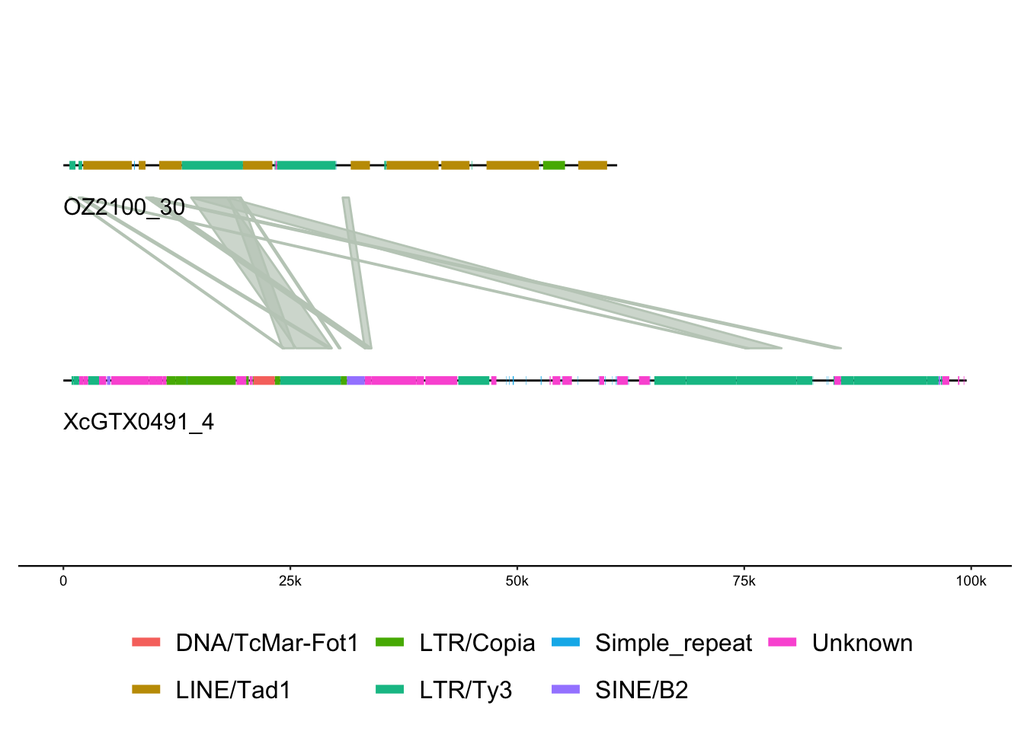

```r
#make new df for sequences
seqs <- tibble::tibble(seq_id = c("OZ2100_30","XcGTX0491_4"),
  start = c(419500,1739500),
  end = c(480500,1839000))
seqs$length<-seqs$end - seqs$start +1

#make gff with repeats
repeats<-rbind(earlgrey_GTX0491_lrar,earlgrey_SAMEA111342678_lrar)
repeats$V9 = paste0("ID=feat_id",1:nrow(repeats),";family=",repeats$family)
write.table(repeats,"../analysis_and_temp_files/03_starfish/lrar_two.gff",quote=F,col.names=F,row.names=F,sep="\t")
repeats <- read_feats("../analysis_and_temp_files/03_starfish/lrar_two.gff")

#make link dataset
links <- blast2 %>% mutate(seq_id="OZ2100_30",seq_id2="XcGTX0491_4",strand="-") %>%
  dplyr::rename(start=OZ2100_30_start,end=OZ2100_30_end,start2=XcGTX0491_4_start,end2=XcGTX0491_4_end) %>%
  select(seq_id,seq_id2,start,end,start2,end2,strand)


gggenomes(seqs = seqs,links = links) %>%
  add_feats(repeats ) %>%
  flip(2)+
  geom_seq()+
  geom_feat(data=feats(repeats),aes(color=type), position="identity")+
  geom_link() +
  geom_seq_label(size=4)+
  theme(legend.text = element_text(size=12),
      legend.titile = element_text(size=8),
      legend.position="bottom")+
  labs(fill="",color="")
```

```r
ggsave("../results/lrar_blast.png",width=8,height = 4)
ggsave("../results/lrar_blast.pdf",width=8,height = 4)
```

- Could it be that unknown is RIped LINE/Tad? Tried aligning, but it doesn’t seem like anything
- Tried de-RIPing by replacing TA to CA and TG

```r
cp analysis_and_temp_files/03_starfish/LRAR.fa analysis_and_temp_files/03_starfish/LRAR_deRIP1.fa
sed -i -e 's/TA/CA/g' analysis_and_temp_files/03_starfish/LRAR_deRIP1.fa

source package /tgac/software/testing/bin/mafft-7.271; mafft --thread 20 analysis_and_temp_files/03_starfish/LRAR_deRIP1.fa > analysis_and_temp_files/03_starfish/LRAR_deRIP1_aligned.fa

cp analysis_and_temp_files/03_starfish/LRAR.fa analysis_and_temp_files/03_starfish/LRAR_deRIP2.fa
sed -i -e 's/TA/TG/g' analysis_and_temp_files/03_starfish/LRAR_deRIP2.fa

source package /tgac/software/testing/bin/mafft-7.271; mafft --thread 20 analysis_and_temp_files/03_starfish/LRAR_deRIP2.fa > analysis_and_temp_files/03_starfish/LRAR_deRIP2_aligned.fa
```

- Did blast search as before, but it didn’t improve the mapping

```r
blast <- read.delim2("../analysis_and_temp_files/03_starfish/lrar_blast_deRIP1.txt",skip=7,header=F)
blast <- blast %>% mutate(strand = if_else(V9<V10,"+","-")) %>%
  mutate(OZ2100_30_start = if_else(V9<V10,V9+419500,V10+419500),
         OZ2100_30_end = if_else(V9<V10,V10+419500,V9+419500),
        XcGTX0491_4_start = 1839000-V8,
        XcGTX0491_4_end = 1839000-V7)

library(GenomicRanges)
blast_OZ2100_30 <- GRanges(seqnames=rep("OZ2100_30",nrow(blast)),
         ranges=IRanges(start=blast$OZ2100_30_start,end=blast$OZ2100_30_end),
         strand=blast$strand)
blast_XcGTX0491_4 <- GRanges(seqnames=rep("XcGTX0491_4",nrow(blast)),
         ranges=IRanges(start=blast$XcGTX0491_4_start,end=blast$XcGTX0491_4_end),
         strand=blast$strand)

#check with overlaps with repeats for SAMEA115359166
earlgrey_SAMEA111342678_lrar_grange <- GRanges(seqnames=rep("OZ2100_30",nrow(earlgrey_SAMEA111342678_lrar)),
         ranges=IRanges(start=earlgrey_SAMEA111342678_lrar$V4,end=earlgrey_SAMEA111342678_lrar$V5),
         type = earlgrey_SAMEA111342678_lrar$V3,
         family = earlgrey_SAMEA111342678_lrar$family)
overlap <-findOverlaps(blast_OZ2100_30,earlgrey_SAMEA111342678_lrar_grange,ignore.strand=F)

#combine info on blast hits and repeats for SAMEA115359166
OZ2100_30_blast_repeat_ranges <-blast_OZ2100_30[overlap@from,]  %>% as.data.frame() %>%
  mutate(OZ2100_repeat_start = earlgrey_SAMEA111342678_lrar_grange[overlap@to,]@ranges@start,
         OZ2100_repeat_end = earlgrey_SAMEA111342678_lrar_grange[overlap@to,]@ranges@width+earlgrey_SAMEA111342678_lrar_grange[overlap@to,]@ranges@start-1,
        OZ2100_repeat_type =  earlgrey_SAMEA111342678_lrar_grange[overlap@to,]$type,
        OZ2100_repeat_family =  earlgrey_SAMEA111342678_lrar_grange[overlap@to,]$family,
       OZ2100_repeat_overlap =width(pintersect(blast_OZ2100_30[from(overlap)], earlgrey_SAMEA111342678_lrar_grange[to(overlap)]))) %>%
  mutate(OZ2100_repeat_overlap=OZ2100_repeat_overlap/width) %>% filter(OZ2100_repeat_overlap>0.05) %>%
  select(start,end,OZ2100_repeat_start,OZ2100_repeat_end,OZ2100_repeat_type,OZ2100_repeat_family,OZ2100_repeat_overlap)
colnames(OZ2100_30_blast_repeat_ranges)[1:2]<-c("OZ2100_30_start" , "OZ2100_30_end")

#check with overlaps with repeats for GTX0491
earlgrey_GTX0491_lrar_grange <- GRanges(seqnames=rep("XcGTX0491_4",nrow(earlgrey_GTX0491_lrar)),
         ranges=IRanges(start=earlgrey_GTX0491_lrar$V4,end=earlgrey_GTX0491_lrar$V5),
         type = earlgrey_GTX0491_lrar$V3,
         family = earlgrey_GTX0491_lrar$family)
overlap2 <-findOverlaps(blast_XcGTX0491_4,earlgrey_GTX0491_lrar_grange,ignore.strand=F)

#combine info on blast hits and repeats for SAMEA115359166
XcGTX0491_4_blast_repeat_ranges <-blast_XcGTX0491_4[overlap2@from,]  %>% as.data.frame() %>%
  mutate(XcGTX0491_4_repeat_start = earlgrey_GTX0491_lrar_grange[overlap2@to,]@ranges@start,
         XcGTX0491_4_repeat_end = earlgrey_GTX0491_lrar_grange[overlap2@to,]@ranges@width+earlgrey_GTX0491_lrar_grange[overlap2@to,]@ranges@start-1,
        XcGTX0491_4_repeat_type =  earlgrey_GTX0491_lrar_grange[overlap2@to,]$type,
        XcGTX0491_4_repeat_family =  earlgrey_GTX0491_lrar_grange[overlap2@to,]$family,
       XcGTX0491_4_repeat_overlap =width(pintersect(blast_XcGTX0491_4[from(overlap2)], earlgrey_GTX0491_lrar_grange[to(overlap2)]))) %>%
  mutate(XcGTX0491_4_repeat_overlap=XcGTX0491_4_repeat_overlap/width) %>%
  select(start,end,XcGTX0491_4_repeat_start,XcGTX0491_4_repeat_end,XcGTX0491_4_repeat_type,XcGTX0491_4_repeat_family,XcGTX0491_4_repeat_overlap) %>% filter(XcGTX0491_4_repeat_overlap>0.05)
colnames(XcGTX0491_4_blast_repeat_ranges)[1:2]<-c("XcGTX0491_4_start" , "XcGTX0491_4_end")

#combine all together
blast2 <- blast[,c(14:17,3,13)] %>% left_join(OZ2100_30_blast_repeat_ranges) %>% left_join(XcGTX0491_4_blast_repeat_ranges) %>% distinct() %>%
  mutate(width_OZ2100=OZ2100_30_end-OZ2100_30_start+1,
        width_XcGTX0491_4=XcGTX0491_4_end-XcGTX0491_4_start+1 )

links <- blast2 %>% mutate(seq_id="OZ2100_30",seq_id2="XcGTX0491_4",strand="-") %>%
  dplyr::rename(start=OZ2100_30_start,end=OZ2100_30_end,start2=XcGTX0491_4_start,end2=XcGTX0491_4_end) %>%
  select(seq_id,seq_id2,start,end,start2,end2,strand)


gggenomes(seqs = seqs,links = links) %>%
 # add_clusters(ortho_assignments) %>%
  add_feats(repeats ) %>%
  flip(2)+
  geom_seq()+
  geom_feat(data=feats(repeats),aes(color=type), position="identity")+
  geom_link() +
  geom_seq_label(size=4)+
  theme(legend.text = element_text(size=7),
      legend.titile = element_text(size=8),
      legend.position="bottom")+
  labs(fill="",color="")
```

[output not shown]